# Cross-Disciplinary Project in R (I): Applied Biostatistical Analysis of Gene Expression in The Simpsons

Jorge Hurtado Soriano

2026-09-30

## 0.1 Workflow Overview

A dataset will be analyzed using R and R Markdown to generate an HTML report through the following steps:

1. **Document setup and library imports**
2. **Introduction and methodological rationale**
3. **Normality analysis**
4. **Principal component analysis (PCA)**
5. **Data visualization**
6. **Individual clustering**
7. **Descriptive analysis stratified by tertiles**
8. **Predictive modeling (logistic regression)**
9. **Results**
10. **Analysis conclusions**
11. **References**

```r
# Dataset analysis workflow in R Markdown:
# 1. Document setup and library imports
# 2. Introduction and methodological rationale
# 3. Normality analysis
# 4. Principal Component Analysis (PCA)
# 5. Data visualization
# 6. Individual clustering
# 7. Descriptive analysis stratified by tertiles
# 8. Predictive modeling (logistic regression)
# 9. Results
# 10. Analysis conclusions
# 11. References

# Configuración del documento y librerías
```

First, the R Markdown file will be configured with the following parameters:

```
# Configure the R Markdown file with the following specifications:

#   * title: "Cross-Disciplinary Project in R (I): Applied Biostatistical Analysis of Gene Expression in The Simpsons"
#   * author: "First Name and 2 Surnames".
#   * date: "yyyy-mm-dd".
#   * output: html_document.

# This will generate the R Markdown file to work with.
```

The following packages will be used:

```r
# R Markdown global configuration
knitr::opts_chunk$set(echo = TRUE, warning = FALSE, message = FALSE)

# Automatic package preparation chunk

# 1. List of all packages required for the project
mis_paquetes <- c(
  "tidyverse", "gtsummary", "gt", "rmarkdown",
  "knitr", "stats", "readr", "dplyr", "tidyr", "factoextra", "reshape", "ggplot2", "car", "pROC", "broom", "kableExtra"
)

# 2. Check which packages are NOT installed
paquetes_faltantes <- mis_paquetes[!(mis_paquetes %in% installed.packages()[,"Package"])]

# 3. Automatically install only missing packages (along with all dependencies)
if(length(paquetes_faltantes) > 0) {
  message("Instalando paquetes faltantes: ", paste(paquetes_faltantes, collapse = ", "))
  install.packages(paquetes_faltantes, dependencies = TRUE)
}
```

```r
# Global R Markdown configuration
# ---------------------------------------------------------
# knitr::opts_chunk$set() defines the default rules for all
# code chunks in the document:
# - echo = TRUE: Displays the source code in the final report.
# - warning = FALSE: Hides minor warnings to keep the document clean.
# - message = FALSE: Silences informational text printed during package loading.

knitr::opts_chunk$set(echo = TRUE, warning = FALSE, message = FALSE)

# Load all required packages for analysis and formatting
# ---------------------------------------------------------

# Bundles essential tools for data manipulation, visualization, and cleaning.
library(tidyverse)

# Package designed for creating automated descriptive statistics tables and analytical
# models ready for academic publication.
library(gtsummary)

# Table design engine. Enables aesthetic customization (borders,
# shading, alignment, titles) of tables generated for the final report.
library(gt)

# Core tool that compiles and renders this code alongside
# text into the final output format (HTML, Word, or PDF).
library(rmarkdown)

# Package responsible for processing and executing each R code chunk,
# allowing plots and tables to be dynamically embedded into the document.
library(knitr)

# Core R package essential for classical statistical analysis.
# Contains shapiro.test() for normality testing and prcomp() for PCA.
library(stats)

# Specialized in fast data import from plain text files,
# such as CSV or tab-delimited datasets.
library(readr)

# Provides data manipulation functions such as select() to filter
# columns or bind_cols() to combine tables.
library(dplyr)

# Facilitates organizing untidy data and handling missing values.
# Works alongside dplyr for dataset preparation.
library(tidyr)

# Extracts complex mathematical results and generates multivariate visualizations
library(factoextra)

# Package required for generating heatmaps
library(pheatmap)

# Used for layer-by-layer graphic construction
library(ggplot2)

# Used for its melt() function, which transforms a two-dimensional
# mathematical matrix into a 3-column table (x, y, value)
# for ggplot2 compatibility
library(reshape)

# For assessing multicollinearity (VIF)
library(car)

# For ROC curve evaluation
library(pROC)

# For easily extracting and tidying model parameters
library(broom)

# For designing, customizing, and styling tables in R Markdown documents
library(kableExtra)
```

The provided dataset is imported to perform the analysis.

```r
# 1. Link to the hosted dataset to allow automated replication of the study
url_drive <- "https://drive.google.com/uc?export=download&id=1g4fhGhpMvN9PG6eArcLrf1Si3QwriXn8&confirm=t"

# 2. Download the file locally
download.file(url_drive, destfile = "simpson_genes.csv", mode = "wb")

# 3. Read the CSV file
simpson_genes <- read_csv("simpson_genes.csv")
```

Limpieza de datos: Se Verifica que no haya datos faltantes en las variables de expresión génica (ADCY3 hasta UHMK1) y si existen NA, se eliminan las filas incompletas.

```r
# 1. Check for missing values (NA) between ADCY3 and UHMK1

gen_NA <- simpson_genes %>%
  select(ADCY3:UHMK1) %>% # Isolates columns from ADCY3 to UHMK1 without needing to list all intermediate variables.
  anyNA()                 # Returns a logical value (TRUE or FALSE) indicating whether at least one NA value exists.

# Convert the logical value to "Yes" or "No" for cleaner presentation
na_result <- ifelse(gen_NA, "Yes", "No")

print(paste("Are there missing values in the gene expression variables?:", na_result))
```

```
## [1] "Are there missing values in the gene expression variables?: No"
```

```r
# 2. Filter dataframe rows to remove NAs only within that specified range

gensimpson_limpio <- simpson_genes %>% # gensimpson_clean will be the clean dataframe used for analysis
  drop_na(ADCY3:UHMK1)                 # Removes only rows containing an NA within the specified gene range.
```

# 1 Introduction

This descriptive analysis was conducted using a simulated dataset inspired by *The Simpsons* universe. The analyzed dataset includes gene expression levels alongside phenotypic and sociodemographic variables associated with the sampled characters. The methodological study in R was structured around two main axes: 1) the evaluation of differential expression as a function of the simulated experimental conditions, and 2) the exploration of variability and dimensionality reduction within the studied population.

# 2 Methodological Rationale

The methodological approach was structured around two main axes: 1) assessing the effect of the simulated experimental conditions, and 2) the stratification and exploration of variance across the sample. Additionally, normality was evaluated because gene expression data commonly follow non-parametric distributions. Therefore, robust statistical methods in R were prioritized, including the Shapiro-Wilk test to assess normality and the non-parametric Wilcoxon test. The analysis was further complemented using medians, interquartile ranges, and multivariate models to ensure biostatistical rigor. The dataset contains clinical information from 59 patients, encompassing a total of 37 genes along with sociodemographic, socioeconomic, identification (character name), anthropometric, and body composition variables, as detailed in the table below.

```r
# 1. Load the external dataset CSV file
# The argument 'show_col_types = FALSE' prevents technical messages from being printed in the console.
info_dataset <- read_csv("Información de interés del dataset.csv", show_col_types = FALSE)

# 2. Construction and styling of the HTML table

# - format = "html": Specifies HTML output format for web/reports.
# - align = "lll": Left-aligns the content of all 3 columns ('l' = left).
# - escape = FALSE: Allows special characters or tags to be parsed correctly.

tabla_variables <- info_dataset %>%
  kable(format = "html", align = "lll", escape = FALSE) %>%

# Applies professional visual styling based on Bootstrap:
# - "striped": Adds alternating row shading (one light, one dark).
# - "hover": Highlights rows when hovering with the mouse cursor.
# - "bordered": Adds clean gridlines and borders around cells.
# - "condensed": Reduces vertical padding to create a more compact table.
# - full_width = FALSE: Prevents the table from stretching across the full page width.

  kable_styling(bootstrap_options = c("striped", "hover", "bordered", "condensed"), full_width = FALSE) %>%

# Inserts a container with vertical scrolling:
# - height = "450px": Limits visual height to 450 pixels to comfortably navigate all 58 rows.

  scroll_box(height = "450px") %>%

# Adds a top header row that unifies and titles the table:
# - c("Dataset Information of Interest" = 3): Spans the title across all 3 columns.
# - font_size = "large": Increases font size for visual hierarchy.
# - bold = TRUE: Sets title text to bold.
# - background = "white": Sets a clean white background for the header bar.

  add_header_above(c("Dataset Information of Interest" = 3),
                   align = "l", font_size = "large", bold = TRUE, background = "white")

# 3. Print the clean table in the HTML document
tabla_variables
```

| Dataset Information of Interest Variable | Dataset Information of Interest Nombre Completo | Dataset Information of Interest Label |
| --- | --- | --- |
| nombre | NA | NA |
| edad_anios | Edad | En años. |
| sexo | Sexo | Masculino, femenino, u otras identidades de género. |
| altura | Altura | Medida de la estatura en centímetros o metros. |
| peso_kg | Peso | Masa corporal en kilogramos. |
| imc_kg_m2 | Índice de Masa Corporal (IMC) | Relación entre el peso y la altura (kg/m²). |
| ccintura_cm | Circunferencia de la cintura | Medida en centímetros que indica la distribución de grasa abdominal. |
| ccadera_cm | Circunferencia de la cadera | Medida en centímetros que ayuda a evaluar la distribución de grasa corporal. |
| grasa_corporal_pct | Porcentaje de grasa corporal | Medida de la cantidad de grasa en relación con el peso total. |
| longitud_brazos_cm | Pliegues cutáneos | Mediciones de la grasa subcutánea en diferentes partes del cuerpo (tríceps, bíceps, subescapular, suprailiaca, etc.). |
| longitud_piernas_cm | Longitud de brazos y piernas | Medidas que pueden ayudar a evaluar la proporción corporal. |
| diametro_biacromial_cm | Diámetro biacromial | Distancia entre los puntos más externos de los hombros. |
| diametro_bicrestal_cm | Diámetro bicrestal | Distancia entre los puntos más externos de las crestas ilíacas. |
| estado_civil | Estado civil | Soltero, casado, divorciado, viudo. |
| nivel_educativo | Nivel educativo | Primaria, secundaria, educación superior, etc. |
| ocupacion | Ocupación | Profesión o actividad laboral. |
| ingreso_anual_usd | Ingreso económico | Nivel de ingresos familiares o personales. |
| lugar_residencia | Lugar de residencia | Urbano, rural; localidad, región, etc. |
| etnicidad | Etnicidad | Grupo étnico o racial al que pertenece la persona. |
| situacion_vivienda | Situación de vivienda | Propia, alquilada, condiciones de habitabilidad. |
| composicion_familiar | Composición familiar | Número de miembros en el hogar y relaciones familiares. |
| enfermedades | Prevalencia de enfermedades | Enfermedades previas y actuales, cirugías, condiciones crónicas. |
| medicamentos | Medicamentos | Uso actual de medicamentos, tratamientos, y dosis. |
| frutas_g_d | Frutas (g/d) | gramos dia en el ultimo año |
| verduras_g_d | Verduras (g/d) | gramos dia en el ultimo año |
| cereales_g_d | Cereales (g/d) | gramos dia en el ultimo año |
| legumbres_g_d | Legumbres (g/d) | gramos dia en el ultimo año |
| frutos_secos_g_d | Frutos secos (g/d) | gramos dia en el ultimo año |
| lacteos_g_d | Lácteos (g/d) | gramos dia en el ultimo año |
| carnes_g_d | Carnes (g/d) | gramos dia en el ultimo año |
| pescados_g_d | Pescados (g/d) | gramos dia en el ultimo año |
| huevos_g_d | Huevos (g/d) | gramos dia en el ultimo año |
| aceites_g_d | Aceites (g/d) | gramos dia en el ultimo año |
| bolleria_industrial_g_d | bolleria industrial (g/d) | gramos dia en el ultimo año |
| af_moderada_h_semana | AF moderada (h/semana) | NA |
| af_intensa_h_semana | AF intensa (h/semana) | NA |
| tabaco | tabaco (fumador, exfumador, no fumador) | NA |
| alcohol | alcohol (frecuente, moderado, social, abstemio) | NA |
| pad_mmhg | PAD | NA |
| pas_mmhg | PAS | NA |
| glucosa_mg_dl | Glucosa | NA |
| tg_mg_dl | TG | NA |
| colesterol_total_mg_dl | Colesterol total | NA |
| ldl_mg_dl | LDL | NA |
| hdl_mg_dl | HDL | NA |
| albumina_g_dl | albumina | NA |
| bilirrubina_mg_dl | bilirrubina | NA |
| ast_u_l | Aspartato aminotransferasa | NA |
| alt_u_l | Alanina aminotransferasa | NA |
| fosfatasa_alcalina_u_l | Fosfatasa alcalina | NA |
| creatinina_mg_dl | Creatinina | NA |
| urea_mg_dl | Urea | NA |
| il6_pg_ml | IL6 | NA |
| tnf_alpha_pg_ml | TNF-alpha | NA |
| ansiedad | ansiedad | NA |
| depresion | depresion | NA |
| trastornos | trastornos | NA |
| cirugias | cirugias | NA |

# 3 Hypothesis

Variability in the expression of the 37 evaluated genes is not random; rather, it establishes specific transcriptional profiles that directly correlate with the population’s metabolic phenotype (determined by BMI, body fat percentage, and biochemical markers such as glucose and lipids). It is hypothesized that dimensionality reduction (PCA) will identify genetic clusters that distinguish individuals at higher clinical risk.

# 4 Main Objective

“To analyze the dataset using the phenotypic, sociodemographic, and gene expression profiles of *The Simpsons* population through normality testing, dimensionality reduction, and the calculation of descriptive and comparative statistics stratified by study conditions.”

## 4.1 Secondary Objectives

1. Evaluate the normal distribution of gene expression within the sample using statistical tests to determine whether parametric (Shapiro-Wilk) or non-parametric (Wilcoxon) statistics should be applied.
2. Compare the genetic profiles of the characters based on the experimental and clinical variables simulated in the environment.
3. Analyze the gene expression matrix by implementing multivariate analysis techniques, such as Principal Component Analysis (PCA), to identify population clustering patterns.

# 5 Methodology

## 5.1 Normality Analysis

To evaluate whether the gene expression data follow a normal distribution, the Shapiro-Wilk test was employed, contrasting the data against the theoretical Gaussian bell curve model, which assumes that expected values under normality fall within a **95% confidence interval**. For the statistical decision rule, a significance level of **$\alpha = 0.05$** was established, whose complement corresponds to a confidence level of **$1 - \alpha = 0.95$**.

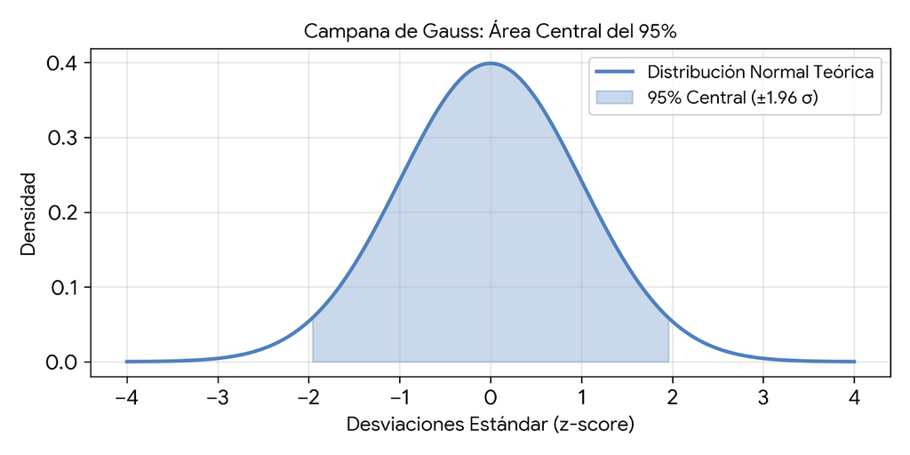

EConsequently, to validate this statistical assumption, the following hypotheses were formally stated:

**Hypothesis Formulation and Decision Rule:** To formally evaluate the normality assumption for each gene variable, the following statistical hypotheses were established:

- **A) Null Hypothesis ($H_0$): The gene expression data originate from a normally distributed population.**
- **B) Alternative Hypothesis ($H_1$): The gene expression data do not follow a normal distribution.**

The decision rule was structured by comparing the obtained $p$-value against the established significance level **($\alpha = 0.05$)**:

- If **$p$-value $> 0.05$**: Fail to reject the null hypothesis ($H_0$), assuming that the data follow a normal distribution.
- If **$p$-value $< 0.05$**: Reject the null hypothesis ($H_0$), concluding that the data do not fit a normal distribution (justifying the subsequent use of non-parametric statistics, such as the median and interquartile range).

```r
# 1. Identify genes automatically
# ---------------------------------------------------------
# We use select() to specify the column range (from ADCY3 to UHMK1).
# Then, names() extracts only the names of those columns and saves them
# as a character vector in 'gene_list'.

lista_genes <- gensimpson_limpio %>%
  select(ADCY3:UHMK1) %>%
  names()

# 2. Create empty vectors to store results

# We create two empty vectors with the same length as our gene list:
# one numeric ('p_values') and one character ('interpretation').

p_valores <- numeric(length(lista_genes))
interpretacion <- character(length(lista_genes))

# 3. Loop (for loop) to calculate Shapiro-Wilk for each gene

# seq_along() creates a numeric sequence from 1 to the total number of genes.
# The loop will automatically repeat the following instructions for each gene.

for(i in seq_along(lista_genes)){

  # Select the gene name corresponding to the current iteration of the loop.
  gen_actual <- lista_genes[i]

  # Extract only the column for that gene using double square brackets [[ ]].
  # na.omit() removes any missing values (NA), as the
  # Shapiro-Wilk test generates an error if empty cells are detected.

  datos_gen <- na.omit(gensimpson_limpio[[gen_actual]])

  # Apply the Shapiro-Wilk normality test to the clean data.
  # Using $p.value, we strictly extract the p-value (ignoring the W statistic).

  p_val <- shapiro.test(datos_gen)$p.value

  # Save the results in our empty vectors at position 'i'.
  # ifelse() evaluates: if the p-value is very small (<0.0001), it saves it in
  # scientific notation ("%.1e") to avoid filling the table with zeros; otherwise,
  # it rounds it to 3 decimal places ("%.3f").

  p_valores[i] <- ifelse(p_val < 0.0001, sprintf("%.1e", p_val), sprintf("%.3f", p_val))

  # Compare the p-value against our significance level (alpha = 0.05).
  # If p > 0.05, the distribution is "Normal". If less than 0.05, "Non-normal".

  interpretacion[i] <- ifelse(p_val > 0.05, "Normal", "Non-normal")
}

# 4. Construction and design of the final table

# Combine all our results into a tibble.
tabla_1 <- tibble(
  "Variable" = lista_genes,  # Column 1: Names of the analyzed genes.
  # rep() repeats the text "Shapiro-Wilk" for all table rows
  "Test used" = rep("Shapiro-Wilk", length(lista_genes)),
  "p-value" = p_valores,   # Column 3: p-values obtained from the normality test.
  "Interpretation" = interpretacion  # Column 4: Textual result ("Non-normal" or "Normal").
) %>%

# 5. Table formatting with gt()
# Pass the table directly to the gt() function for visual formatting.
gt() %>%

  # Add the title. The md() function with
  # asterisks "**" will make "Model Table 1." bold.
  tab_header(
    title = md("**Model Table 1.** Gene expression normality analysis")
  ) %>%

  # Center the content of all columns.
  cols_align(   # 'cols_align()' adjusts horizontal text positioning.
    align = "center",   # - align = "center": Centers the content.
    # - columns = everything(): Applies this centering to absolutely all table columns.
    columns = everything()
  ) %>%

  # Header row style: light gray background and bold text.
  tab_style( # 'tab_style()' allows applying specific styling rules to concrete zones.
    style = list(
      cell_fill(color = "#EFEFEF"),  # - cell_fill(color = "#EFEFEF"): Paints header background a very light gray.
      cell_text(weight = "bold") # - cell_text(weight = "bold"): Changes column title typography to bold.
    ),

    # - locations = cells_column_labels(): Specifies that this style only affects top column labels.
    locations = cells_column_labels(columns = everything())
  ) %>%

  # Draw a complete grid by placing 1-pixel black borders
  # on both the table body and the column labels.
  tab_style(
    style = cell_borders( # 'cell_borders()' draws dividing lines in the table.
      sides = "all", # - sides = "all": Draws all four sides (top, bottom, left, right) of each cell.
      color = "black", # - color = "black" and weight = px(1): Defines solid black borders with 1-pixel thickness.
      weight = px(1)
    ),
    locations = list( # - locations = list(cells_body(), cells_column_labels()): Applies this grid to both
      # body cells and headers, achieving a classic grid structure.
      cells_body(),
      cells_column_labels()
    )
  ) %>%

  # Force perimeter lines (top and bottom of table) to be solid black.
  tab_options(  # 'tab_options()' modifies global options of the table structure.
    table.border.top.color = "black",
    table.border.bottom.color = "black",
    table_body.border.bottom.color = "black"
  ) %>%

  # Add footnote with methodological specifications of the test.
  tab_source_note(
    source_note = "Note: N=59. The Shapiro-Wilk statistical test was applied. A p-value < 0.05 assumes a Non-normal distribution."
  )

tabla_1
```

**Model Table 1.** Gene expression normality analysis

| Variable | Test used | p-value | Interpretation |
| --- | --- | --- | --- |
| ADCY3 | Shapiro-Wilk | 1.1e-08 | Non-normal |
| AGRP | Shapiro-Wilk | 1.3e-09 | Non-normal |
| ANKRD27 | Shapiro-Wilk | 6.5e-08 | Non-normal |
| ANO4 | Shapiro-Wilk | 8.0e-10 | Non-normal |
| BDNF | Shapiro-Wilk | 2.8e-11 | Non-normal |
| CADM1 | Shapiro-Wilk | 3.1e-06 | Non-normal |
| CADM2 | Shapiro-Wilk | 8.4e-11 | Non-normal |
| CALCR | Shapiro-Wilk | 8.7e-07 | Non-normal |
| CNR1 | Shapiro-Wilk | 2.5e-07 | Non-normal |
| CREBRF | Shapiro-Wilk | 8.4e-10 | Non-normal |
| DPP9 | Shapiro-Wilk | 4.6e-06 | Non-normal |
| FTO | Shapiro-Wilk | 7.5e-06 | Non-normal |
| GIPR | Shapiro-Wilk | 2.5e-07 | Non-normal |
| GPR151 | Shapiro-Wilk | 0.000 | Non-normal |
| GPR75 | Shapiro-Wilk | 8.7e-08 | Non-normal |
| KIAA0586 | Shapiro-Wilk | 4.6e-06 | Non-normal |
| KIAA1109 | Shapiro-Wilk | 7.7e-05 | Non-normal |
| KSR2 | Shapiro-Wilk | 1.1e-06 | Non-normal |
| LEP | Shapiro-Wilk | 2.1e-09 | Non-normal |
| LEPR | Shapiro-Wilk | 8.9e-08 | Non-normal |
| MC4R | Shapiro-Wilk | 4.5e-05 | Non-normal |
| MRAP2 | Shapiro-Wilk | 1.0e-11 | Non-normal |
| NRP1 | Shapiro-Wilk | 2.6e-06 | Non-normal |
| NRP2 | Shapiro-Wilk | 7.2e-08 | Non-normal |
| NTRK2 | Shapiro-Wilk | 1.0e-08 | Non-normal |
| PCSK1 | Shapiro-Wilk | 2.3e-06 | Non-normal |
| PDE3B | Shapiro-Wilk | 1.4e-09 | Non-normal |
| PHIP | Shapiro-Wilk | 1.2e-07 | Non-normal |
| POMC | Shapiro-Wilk | 3.6e-08 | Non-normal |
| PPARG | Shapiro-Wilk | 3.4e-08 | Non-normal |
| ROBO1 | Shapiro-Wilk | 1.7e-09 | Non-normal |
| SH2B1 | Shapiro-Wilk | 3.6e-06 | Non-normal |
| SIM1 | Shapiro-Wilk | 8.9e-09 | Non-normal |
| SPARC | Shapiro-Wilk | 2.7e-05 | Non-normal |
| TMEM18 | Shapiro-Wilk | 1.1e-06 | Non-normal |
| UBR2 | Shapiro-Wilk | 1.5e-08 | Non-normal |
| UHMK1 | Shapiro-Wilk | 2.7e-07 | Non-normal |

Note: N=59. The Shapiro-Wilk statistical test was applied. A p-value < 0.05 assumes a Non-normal distribution.

## 5.2 Principal Component Analysis (PCA)

Principal Component Analysis (PCA): A PCA is performed using the gene expression variables (ADCY3 to UHMK1). The variables are centered and scaled prior to running PCA. Additionally, the scores of the first six principal components are extracted, saved, and appended to the data frame, followed by the generation of the corresponding visualizations.

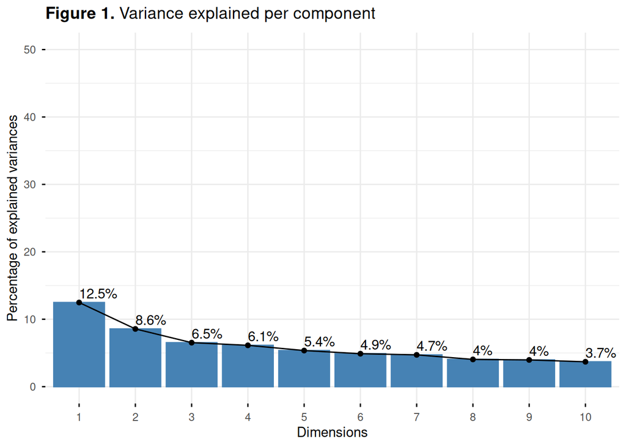

```r
# 1. Data preparation and selection of target genes
# Select genes ADCY3 through UHMK1.
# The pipe operator (%>%) passes the clean dataset to the function.
# The select() function extracts a subset of columns from 'gensimpson_clean'.
# Using the colon operator (:) instructs R to select ALL columns in that range.

genes_pca_date <- gensimpson_limpio %>%
  select(ADCY3:UHMK1)

# 2. Execute centered and scaled PCA
# prcomp() is used with scale. = TRUE to standardize variables.
# - center = TRUE: Centers variables by subtracting the mean of each gene
#   (setting the new mean of all columns to exactly 0).
# - scale. = TRUE: Scales variables by dividing by their standard deviation
#   (setting the variance of all columns to 1).

res_pca <- genes_pca_date %>%
  select(where(~ var(.) > 0)) %>%
  prcomp(center = TRUE, scale. = TRUE)

res_pca <- prcomp(genes_pca_date, center = T, scale. = T)

# 3. Extract scores for the first 6 principal components
# The specific element 'res_pca$x' is a matrix containing the "scores"
# (the newly projected coordinates for each sample) in PC space.
# - [, 1:6]: Brackets filter the matrix. Keeping the space before the comma empty
#   retains all rows (patients). '1:6' after the comma extracts columns 1 through 6.
# - as.data.frame(): Converts the matrix into a data frame.
# This 6-column table is stored in 'scores_pca'.

scores_pca <- as.data.frame(res_pca$x[, 1:6])

# 4. Bind PCA scores to the main dataframe
# bind_cols() combines two data frames side-by-side (column-wise matching).
# It takes the original dataset ('gensimpson_clean') and appends the 6 new
# principal component score columns ('scores_pca') on the right.

dataset_genes_pca <- bind_cols(gensimpson_limpio, scores_pca)


# 5. Visualizations (Figures)

# Dynamically extract variance percentages for axis labels
varianza <- get_eig(res_pca)$variance.percent
etiqueta_x <- sprintf("PC1 (%.1f%%)", varianza[1])
etiqueta_y <- sprintf("PC2 (%.1f%%)", varianza[2])
# Figure 1: Scree plot

# fviz_eig() generates a bar plot showing the variance explained by each PC component.
# - res_pca: Pass the output from the PCA model calculated earlier.
# - addlabels = TRUE: Prints the exact percentage as a label atop each bar.
# - ylim = c(0, 50): Sets Y-axis limits (0 to 50%) to prevent tall bars from distorting scale.
# - + labs(title = "..."): Adds a formal title using ggplot2 syntax.

grafico_varianza <- fviz_eig(res_pca, addlabels = T, ylim = c(0, 50)) +
  labs(title = expression(bold("Figure 1.") ~ "Variance explained per component"))

# Figure 2: Variables plot (Correlation and contribution)

# fviz_pca_var() visualizes variables (genes) in principal component space.
# - col.var = "cos2": Colors variables based on their representation quality (squared cosine).
# - gradient.cols = c("blue", "yellow", "red"): Palette definition. Low cos2 values
#   are blue, medium are yellow, and high are red.
# - repel = TRUE: Automatically adjusts text position to avoid overlapping labels.

grafico_variables <- fviz_pca_var(res_pca, col.var = "cos2",
                               gradient.cols = c("blue", "yellow", "red"),
                               repel = T) +
  labs(title = expression(bold("Figure 2.") ~ "Variables in principal component space"),
        x = etiqueta_x,
        y = etiqueta_y)

# Figure 3: Individuals plot (Sample projections)

# fviz_pca_ind() visualizes observations (patients/individuals) projected onto PC space.
# Useful for observing sample clustering, pattern exploration, and outlier detection.
# - col.ind = "cos2": Colors individuals by cos2 value to evaluate representation quality.

grafico_individuos <- fviz_pca_ind(res_pca, col.ind = "cos2",
                                 gradient.cols = c("blue", "yellow", "red"),
                                 repel = TRUE) +
  labs(title = expression(bold("Figure 3.") ~ "Individual projection on PCA"),
       x = etiqueta_x,
       y = etiqueta_y)

# Figure 4: Biplot (Combined variables and individuals)

# fviz_pca_biplot() combines observations and variables into a single plot
# along the first two principal components.
# - repel = TRUE: Prevents text overlap between gene names and patient IDs.
# - col.var = "#2E9FDF": Sets arrow color for variables (genes) to blue.
# - col.ind = "red": Sets point color for individuals (samples) to red.

grafico_biplot <- fviz_pca_biplot(res_pca, repel = TRUE,
                                  col.var = "#2E9FDF", col.ind = "red") +
  labs(title = expression(bold("Figure 4.") ~ "Overall PCA biplot"),
       x = etiqueta_x,
       y = etiqueta_y)

# Display plots
grafico_varianza
```

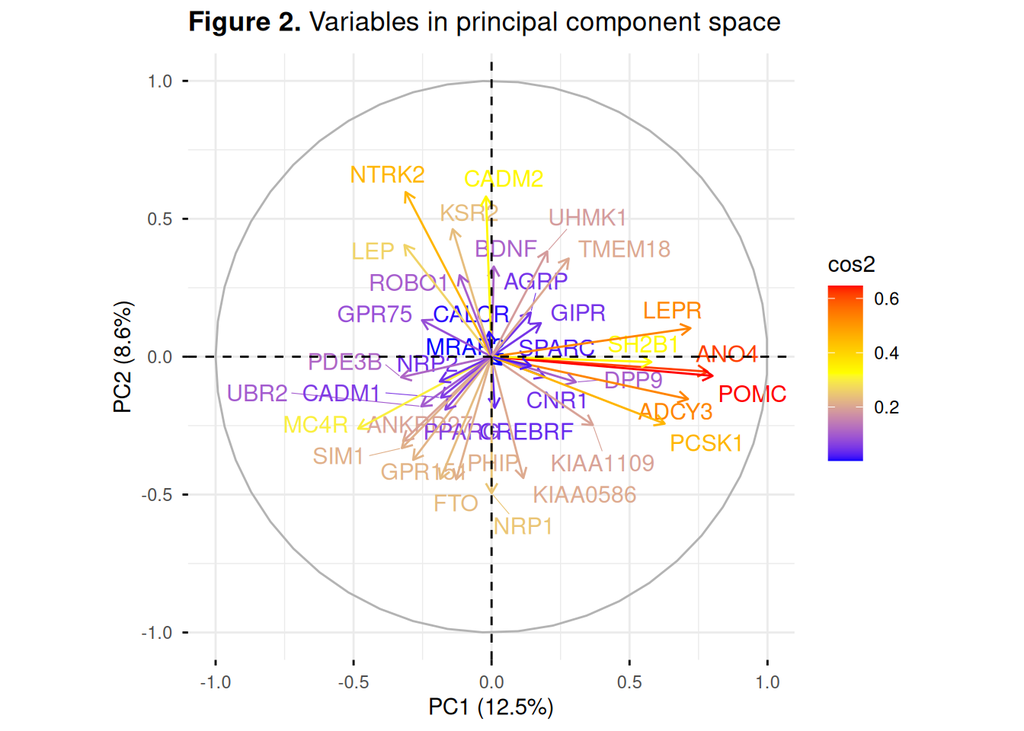

```r
grafico_variables
```

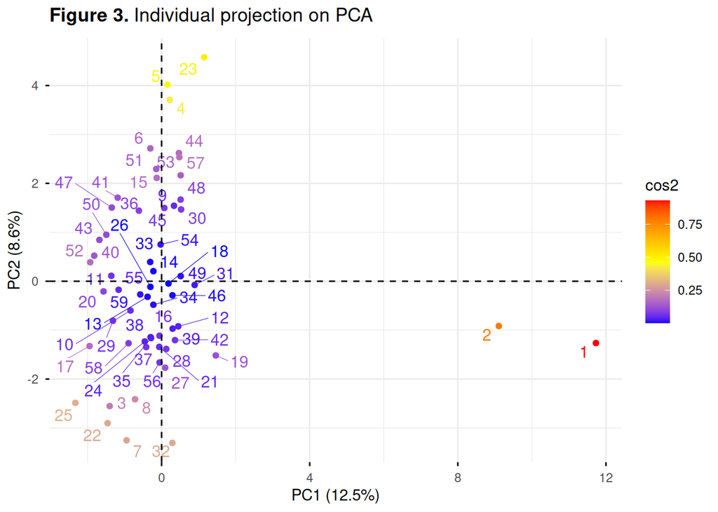

```r
grafico_individuos
```

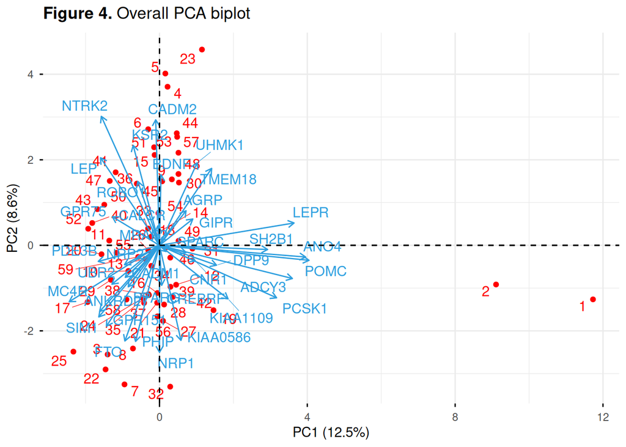

```r
grafico_biplot
```

A Component and R² table is constructed.

```r
# Table generation (Components and R²)
# Extract patient coordinates for the first 6 dimensions
scores_pca <- as.data.frame(res_pca$x[, 1:6])

# Append these 6 new columns to the original dataframe
gensimpson_limpio <- bind_cols(gensimpson_limpio, scores_pca)


# 3. Create Model Table (Components and R²)

# Extract the explained variance (R²) contributed by each component
varianza_pca <- get_eig(res_pca)

# Construct table structure
tabla_varianza <- data.frame(
  # 'Component = paste0("PC", 1:6)' creates the first column of the table:
  # - '1:6' generates a numeric integer sequence from 1 to 6.
  # - 'paste0("PC", ...)' joins the text "PC" with each sequence number
  #   without spaces, generating: "PC1", "PC2", "PC3", "PC4", "PC5", and "PC6".
  Componente = paste0("PC", 1:6),
  # The name '`R²`' is placed in backticks because it
  # contains a special character (superscript '²').
  # - 'pca_variance$variance.percent[1:6]': Extracts percentage values of explained variance
  #   for the first 6 principal components.
  # - 'sprintf("%.2f%%", ...)' formats numbers:
  #   * '%.2f': Formats the number with exactly 2 decimal places.
  #   * '%%': Appends a literal percentage symbol (%) at the end.
  `R²` = sprintf("%.2f%%", varianza_pca$variance.percent[1:6]),
  check.names = FALSE # Prevents R from removing the '²' symbol from the column name
)

# Render table using gt()

# Create a new object named 'pca_model_table'.
# The pipe operator ('%>%') takes 'variance_table'
# and passes it directly to the next styling function.

tabla_modelo_pca <- tabla_varianza %>%

  # The 'gt()' function (Grammar of Tables) converts tabular data
  # into a specialized formatted table object

  gt() %>%
  # 'tab_header()' sets the main header title of the table.
  # - 'md()' allows Markdown syntax:
  #   double asterisks "**" bold the text "**PCA Table: Components and R².**",
  #   followed by regular text.
  tab_header(
    title = md("**PCA Table: Components and R².** Variance explained by the first 6 components")
  ) %>%
  tab_source_note(
    # Add footnote
    source_note = "R² values represent the percentage of variance retained by each principal component"
  ) %>%
  cols_align(align = "center") %>%
  tab_options(  # 'tab_options()' modifies global structural and visual properties of the table:
    table.border.top.color = "black",    # - 'table.border.top.color = "black"': Draws a solid black top border.
    table.border.bottom.color = "black", # - 'table.border.bottom.color = "black"': Draws a solid black bottom border.
    heading.title.font.weight = "bold"   # - 'heading.title.font.weight = "bold"': Ensures main title font weight is bold.
  )

# Print table in the report
tabla_modelo_pca
```

**PCA Table: Components and R².** Variance explained by the first 6 components

| Componente | R² |
| --- | --- |
| PC1 | 12.48% |
| PC2 | 8.56% |
| PC3 | 6.53% |
| PC4 | 6.13% |
| PC5 | 5.36% |
| PC6 | 4.89% |

R² values represent the percentage of variance retained by each principal component

A PCA loadings table is constructed.

```r
# 1. Extract the factor loadings matrix from the PCA object
# Select the first 6 components

# - 'res_pca$rotation': Extracts the rotation matrix or "factor loadings" from the resulting PCA object
# - '[, 1:6]': Selects all rows while restricting columns to the first 6 principal components (PC1 to PC6).
# - 'as.data.frame(...)': Converts the mathematical matrix into a data frame
cargas_matriz <- as.data.frame(res_pca$rotation[, 1:6])

# 2. Convert row names (genes) into a formal column named "Variable"

# In a PCA data frame, gene names are typically stored as row names rather than an actual data column.
# - 'rownames(cargas_matriz)': Extracts those row names.
# - 'cargas_matriz$Variable <- ...': Creates a new column named "Variable" to store gene names, facilitating downstream visualization.
cargas_matriz$Variable <- rownames(cargas_matriz)

# 3. Reorder columns so that "Variable" comes first

# The pipe operator ('%>%') is used alongside the 'dplyr' package:
# - 'select(Variable, everything())': Places the "Variable" column (containing gene names) in the first position, followed by 'everything()' (which re-inserts the remaining principal component columns in their original order).
cargas_matriz <- cargas_matriz %>%
  select(Variable, everything())

# 4. Render the table with aesthetic formatting standards

tabla_modelo_cargas <- cargas_matriz %>%
  gt() %>%
  tab_header(
    title = md("**PCA Loadings Table.** Factor loadings of gene variables across principal components")
  ) %>%

  # Round numeric values to 3 decimal places for a clean presentation

  fmt_number(
    columns = -Variable,
    decimals = 3
  ) %>%
  tab_source_note(
    source_note = md("*Note: Values show the contribution and correlation of each gene with respect to the principal components.*")
  ) %>%
  cols_align(align = "center") %>%
  tab_options(  # 'tab_options()' allows customizing dividing line thickness and color
    table.border.top.color = "black", # - 'table.border.top.color / width = px(2)': Creates a thick black top border (2 pixels).
    table.border.top.width = px(2),
    table.border.bottom.color = "black", # - 'table.border.bottom.color / width = px(2)': Creates a thick black bottom border (2 pixels).
    table.border.bottom.width = px(2),
    heading.border.bottom.color = "black", # - 'heading.border.bottom.color = "black"': Draws a black dividing line below the title.
    column_labels.border.bottom.color = "black", # - 'column_labels.border.bottom.color / width = px(2)': Draws a 2-pixel solid black line
    column_labels.border.bottom.width = px(2)  #   separating column labels from the table body.
  )

# Print the table in your final report

tabla_modelo_cargas
```

**PCA Loadings Table.** Factor loadings of gene variables across principal components

| Variable | PC1 | PC2 | PC3 | PC4 | PC5 | PC6 |
| --- | --- | --- | --- | --- | --- | --- |
| ADCY3 | 0.331 | −0.086 | 0.095 | −0.095 | 0.058 | −0.067 |
| AGRP | 0.066 | 0.090 | 0.103 | 0.214 | −0.221 | −0.216 |
| ANKRD27 | −0.149 | −0.172 | 0.012 | −0.304 | 0.060 | 0.064 |
| ANO4 | 0.364 | −0.030 | 0.026 | 0.040 | −0.103 | −0.128 |
| BDNF | 0.004 | 0.184 | −0.094 | 0.092 | 0.292 | −0.236 |
| CADM1 | −0.085 | −0.083 | −0.061 | 0.219 | −0.224 | 0.293 |
| CADM2 | −0.009 | 0.326 | 0.052 | 0.177 | 0.155 | 0.232 |
| CALCR | −0.004 | 0.051 | 0.079 | 0.220 | −0.180 | 0.181 |
| CNR1 | 0.090 | −0.041 | −0.118 | −0.191 | −0.148 | −0.011 |
| CREBRF | 0.005 | −0.104 | 0.329 | 0.068 | 0.149 | 0.114 |
| DPP9 | 0.142 | −0.052 | 0.089 | 0.285 | 0.367 | −0.076 |
| FTO | −0.086 | −0.249 | 0.303 | −0.047 | 0.202 | −0.103 |
| GIPR | 0.083 | 0.068 | 0.134 | 0.077 | 0.363 | 0.384 |
| GPR151 | −0.132 | −0.210 | −0.060 | −0.180 | −0.084 | −0.017 |
| GPR75 | −0.117 | 0.074 | −0.098 | −0.039 | 0.019 | −0.336 |
| KIAA0586 | 0.054 | −0.247 | −0.261 | 0.161 | −0.089 | 0.171 |
| KIAA1109 | 0.171 | −0.139 | 0.168 | −0.111 | −0.172 | 0.191 |
| KSR2 | −0.066 | 0.260 | 0.191 | −0.134 | −0.191 | 0.186 |
| LEP | −0.147 | 0.228 | 0.094 | −0.131 | 0.223 | 0.006 |
| LEPR | 0.335 | 0.058 | −0.072 | −0.164 | 0.014 | −0.095 |
| MC4R | −0.225 | −0.147 | 0.088 | 0.299 | 0.012 | −0.182 |
| MRAP2 | 0.017 | −0.016 | −0.422 | 0.028 | 0.118 | −0.045 |
| NRP1 | 0.000 | −0.278 | −0.138 | 0.078 | 0.073 | 0.176 |
| NRP2 | −0.087 | −0.050 | 0.116 | 0.140 | −0.208 | −0.272 |
| NTRK2 | −0.145 | 0.335 | −0.027 | −0.107 | −0.002 | −0.031 |
| PCSK1 | 0.292 | −0.136 | −0.019 | −0.063 | −0.039 | 0.072 |
| PDE3B | −0.153 | −0.042 | 0.192 | 0.126 | −0.268 | 0.109 |
| PHIP | −0.060 | −0.250 | 0.253 | −0.168 | 0.109 | −0.009 |
| POMC | 0.373 | −0.039 | 0.065 | −0.014 | 0.028 | −0.003 |
| PPARG | −0.078 | −0.108 | −0.164 | −0.271 | 0.089 | 0.043 |
| ROBO1 | −0.054 | 0.166 | 0.130 | −0.418 | −0.067 | 0.124 |
| SH2B1 | 0.269 | −0.011 | 0.232 | −0.047 | −0.060 | −0.182 |
| SIM1 | −0.151 | −0.186 | 0.139 | −0.058 | 0.250 | −0.116 |
| SPARC | 0.066 | −0.019 | −0.244 | −0.029 | 0.137 | 0.204 |
| TMEM18 | 0.130 | 0.200 | 0.187 | 0.087 | 0.013 | 0.121 |
| UBR2 | −0.119 | −0.101 | 0.149 | −0.071 | −0.097 | −0.054 |
| UHMK1 | 0.094 | 0.215 | −0.018 | −0.085 | −0.058 | −0.142 |

*Note: Values show the contribution and correlation of each gene with respect to the principal components.*

## 5.3 Visualization

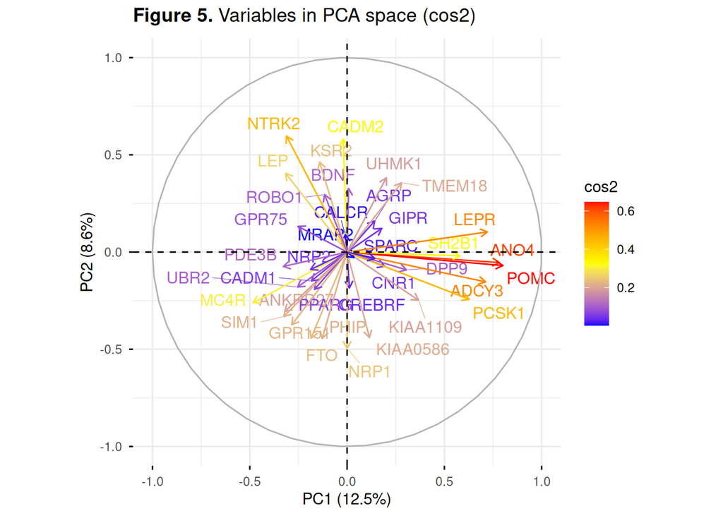

```r
# 1. Variables plot by quality of representation (cos2)

# A map is generated where genes are colored according to their 'cos2' value.
# cos2 measures how well a variable is represented in the two plotted dimensions.
# Red arrows indicate excellent representation, whereas blue arrows indicate
# that the gene has minimal relevance in this specific plane.

fig_var_cos2 <- fviz_pca_var(res_pca,
                             col.var = "cos2", # Colors according to quality of representation (cos2)
                             gradient.cols = c("blue", "yellow", "red"), # Gradient palette (blue=low, red=high)
                             repel = T) +  # Prevents text label overlap
  labs(title = expression(bold("Figure 5.") ~ "Variables in PCA space (cos2)"),
       x = etiqueta_x, # Dynamic label for X axis
       y = etiqueta_y) # Dynamic label for Y axis

# 2. Variable clustering (3 groups) based on coordinates

# First, extract the exact coordinates for each gene in PCA space.
coord_var <- get_pca_var(res_pca)$coord[, 1:2]

# Apply k-means searching for 3 clusters among variables to identify 3 groups of
# genes with similar expression behavior.
# set.seed(123) ensures reproducible results.

set.seed(123)
cluster_var <- kmeans(coord_var, centers = 3)


# Dynamically extract percentage of variance explained from the PCA model
# This avoids manually typing "(%)".

varianza <- get_eig(res_pca)$variance.percent
etiqueta_x <- sprintf("PC1 (%.1f%%)", varianza[1]) # Formats X axis text to 1 decimal place
etiqueta_y <- sprintf("PC2 (%.1f%%)", varianza[2]) # Formats Y axis text to 1 decimal place

# Visualization of variable clustering
# Plot genes colored by their assigned mathematical cluster.

fig_var_cluester <- fviz_pca_var(res_pca,
                                 col.var = as.factor(cluster_var$cluster), # Converts cluster to categorical factor for coloring
                                 palette = c("#2E9FDF", "#E7B800", "#FC4E07"), # Specific colors for the 3 groups
                                 legend.title = "Var Cluster", # Title for side legend
                                 repel = T) + # Separates labels to prevent overlap
  labs(title = expression(bold("Figure 6.") ~ "Variable clustering (3 groups)"),
       x = etiqueta_x,
       y = etiqueta_y)


# 3. Variable contribution plots to components

# fviz_contrib() generates a bar plot strictly displaying
# the top 10 genes (top = 10) contributing most to the construction
# of the first principal component (axes = 1).

fig_contrib_dim1 <- fviz_contrib(res_pca, choice = "var", axes = 1, top = 10) +
  labs(title = expression(bold("Figure 7.") ~ "Variable contribution to Dimension 1"))

# 4. BMI category creation and individuals plot
# We use dplyr (mutate and case_when) to transform numerical BMI
# into clinical categories

gensimpson_limpio <- gensimpson_limpio %>%
  mutate(categoria_imc = case_when(
    imc_kg_m2 < 18.5 ~ "Underweight",
    imc_kg_m2 >= 18.5 & imc_kg_m2 < 25 ~ "Normal",
    imc_kg_m2 >= 25 & imc_kg_m2 < 30 ~ "Overweight",
    imc_kg_m2 >= 30 ~ "Obesity"
  ))

# 3.1 Variable contribution plots to components

# fviz_contrib() generates a bar plot strictly displaying
# the top 10 genes (top = 10) contributing most to the construction
# of the second principal component (axes = 2).

fig_contrib_dim2 <- fviz_contrib(res_pca, choice = "var", axes = 2, top = 10) +
  labs(title = expression(bold("Figure 7.1") ~ "Variable contribution to Dimension 2"))

# Plot individuals colored by their BMI category with confidence ellipses

# Project patients (individuals) colored by their weight classification.
# addEllipses = TRUE draws an ellipse enclosing the 95% confidence interval
# for each group, allowing visual assessment of group separation (e.g., obese vs. normal).

fig_ind_imc <- fviz_pca_ind(res_pca,
                            col.ind = gensimpson_limpio$categoria_imc,  # Colors according to created BMI category
                            palette = c("#00AFBB", "#E7B800", "#FC4E07", "#2E9FDF"), # Colors for each BMI group
                            addEllipses = TRUE,   # Draws statistical ellipses around groups
                            ellipse.type = "confidence", # Ellipse type based on 95% confidence interval
                            repel = TRUE) +  # Prevents patient label overlap
  labs(title = expression(bold("Figure 8.") ~ "Individuals in PCA space by BMI Category"),
       x = etiqueta_x,
       y = etiqueta_y)

# 5. Individual clustering (3 groups) based on PCA scores

# Apply K-means to patients.
# Extract their scores on the first two principal components.

scores_ind <- res_pca$x[, 1:2]

# The algorithm groups patients into 3 clusters
# based strictly on their overall gene expression profile.

set.seed(123)
cluster_ind <- kmeans(scores_ind, centers = 3)

# Visualize individual clustering with ellipses

fig_ind_cluster <- fviz_pca_ind(res_pca,
                                col.ind = as.factor(cluster_ind$cluster), # Colors according to individual cluster number
                                palette = c("#2E9FDF", "#E7B800", "#FC4E07"), # Color palette for the 3 patient clusters
                                addEllipses = TRUE,  # Adds confidence ellipses
                                legend.title = "Ind Cluster", # Legend title
                                repel = TRUE) +  # Prevents overlapping labels
  labs(title = expression(bold("Figure 9.") ~ "Individual clustering (3 groups)"),
       x = etiqueta_x,
       y = etiqueta_y)

# Print plots
fig_var_cos2
```

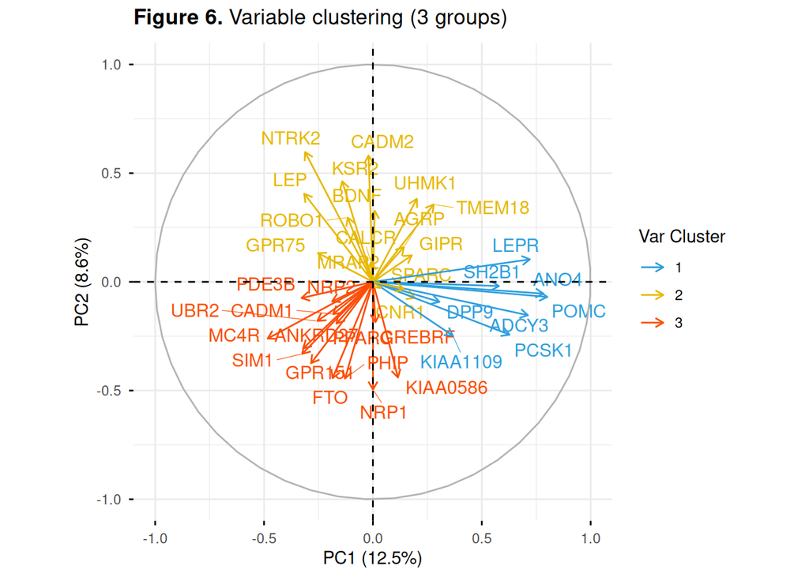

```r
fig_var_cluester
```

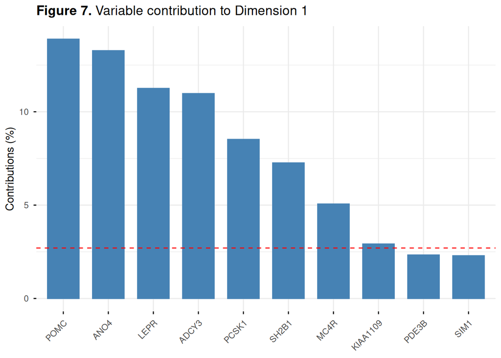

```r
fig_contrib_dim1
```

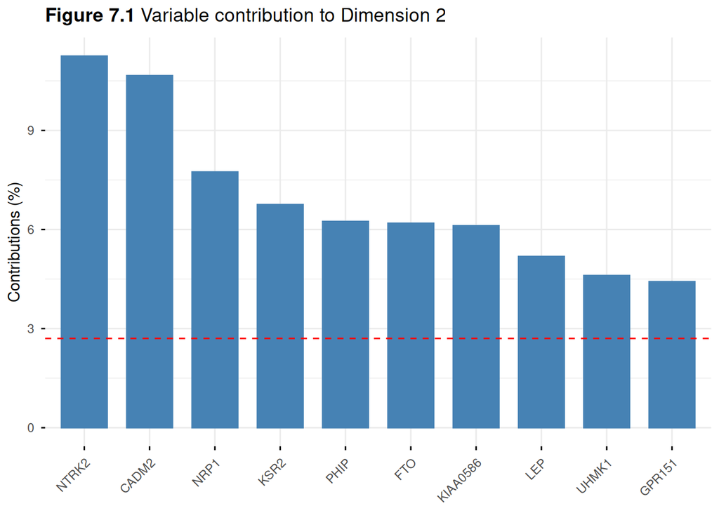

```r
fig_contrib_dim2
```

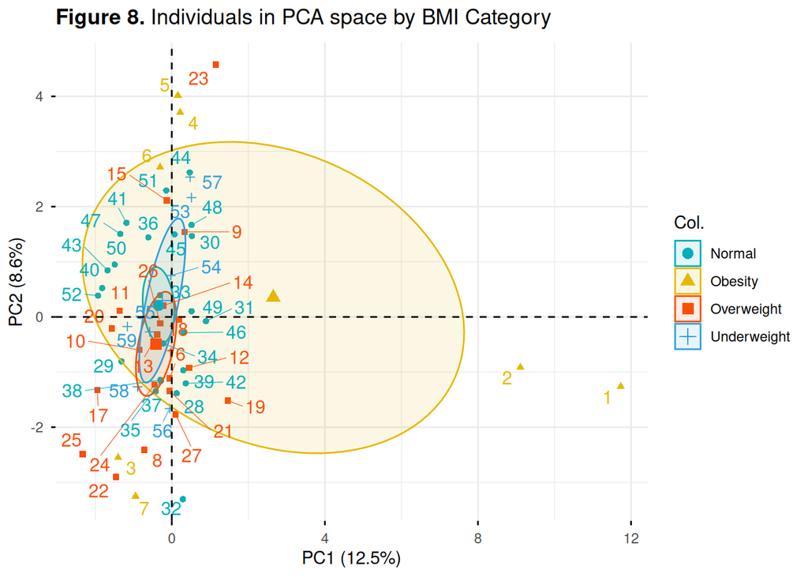

```r
fig_ind_imc
```

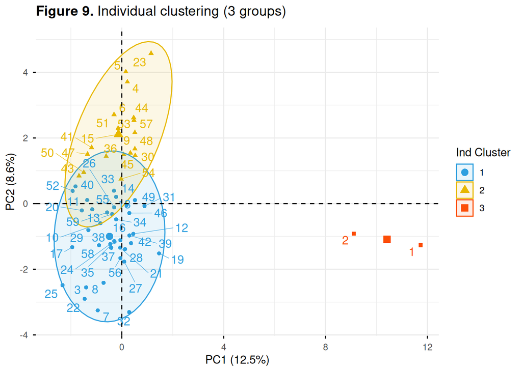

```r
fig_ind_cluster
```

## 5.4 Individual Clustering

Additionally, to complement the exploratory analysis, heatmaps were implemented. On one hand, Spearman correlations between genetic variables and the first six principal components were presented; on the other hand, raw expression data were visualized to examine and verify gene expression patterns across individuals.

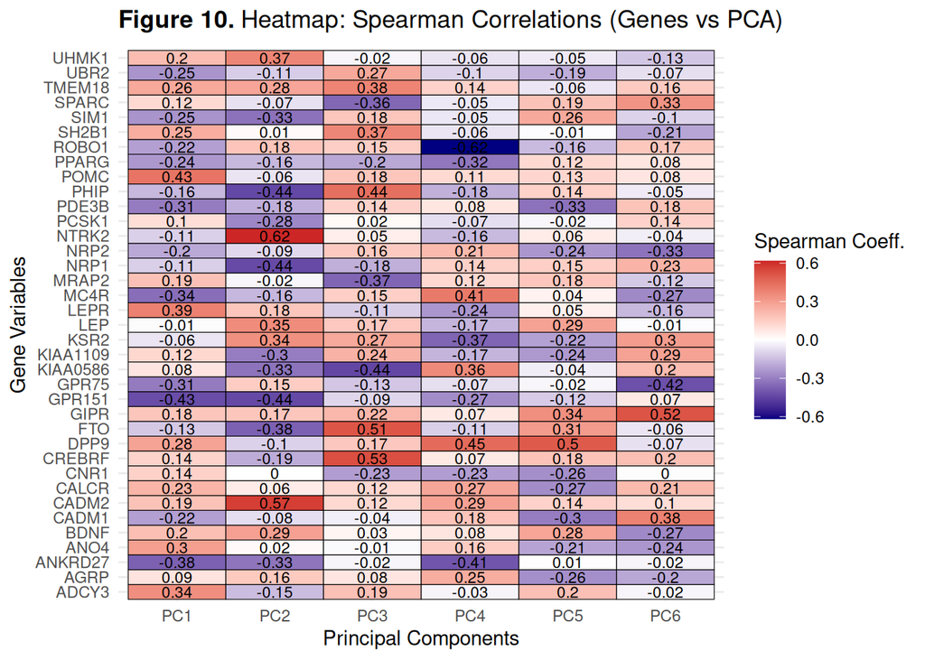

```r
# Base data extraction (ensuring only genes and the 6 components are included)

# - 'select(ADCY3:UHMK1)': Selects only the columns corresponding to genes
#   (from ADCY3 to UHMK1) within the clean dataframe, creating a pure expression matrix.
genes_matriz <- gensimpson_limpio %>% select(ADCY3:UHMK1)

# - 'res_pca$x[, 1:6]': Extracts the coordinates or scores of individuals
#   across the first 6 principal components of the PCA and converts them into a data frame.
scores_pca <- as.data.frame(res_pca$x[, 1:6])

# 1. Spearman correlation heatmap (Genes vs 6 Components)

# A) Mathematical calculation
# Calculate Spearman correlation between each gene and each component

# The 'cor()' function calculates the Spearman correlation coefficient
# crossing each gene against each of the 6 principal components.

matriz_correlacion <- cor(genes_matriz, scores_pca, method = "spearman")

# B) Reshaping data format (Melt)
# 'melt()' converts the two-dimensional correlation matrix into a long-format data frame
# (with 3 columns), which is the standard format required by ggplot2.

df_corr <- melt(matriz_correlacion)

# Rename columns of the new dataframe
colnames(df_corr) <- c("Gen", "Componente", "Correlacion")


# C) Plot construction using geom_tile()

heatmap_spearman <- ggplot(df_corr, aes(x = Componente, y = Gen, fill = Correlacion)) +
  # Draws heatmap rectangles (cells) with a thin black border.
  geom_tile(color = "black") +
  # Adds the exact numerical correlation value inside each cell,
  # rounded to 2 decimal places with a small font size (size = 3).
  geom_text(aes(label = round(Correlacion, 2)), color = "black", size = 3) + # Numerical values
  # Sets a divergent color scale:
  # Navy blue ('navy') for negative correlations, white at midpoint (0),
  # and intense red ('firebrick3') for positive correlations.
  scale_fill_gradient2(low = "navy", mid = "white", high = "firebrick3", midpoint = 0) +
  labs(title = expression(bold("Figure 10.") ~ "Heatmap: Spearman Correlations (Genes vs PCA)"),
       x = "Principal Components",
       y = "Gene Variables",
       fill = "Spearman Coeff.") +
  theme_minimal()

# 2. Raw data heatmap (Expression patterns per individual)

# A) Mathematical standardization
# Raw data are scaled so all genes become visually comparable
matriz_cruda_escalada <- scale(as.matrix(genes_matriz))

# B) Name assignment
# Creates custom labels ("Patient 1", "Patient 2", etc.)
# to individually identify each subject on the vertical axis of the heatmap.
rownames(matriz_cruda_escalada) <- paste("Patient", 1:nrow(matriz_cruda_escalada))

# C) Reshaping data format (Melt)

# Transforms scaled matrix of patients and genes into a long table compatible with ggplot2.
df_crudo <- melt(matriz_cruda_escalada)

# Renames resulting columns.
colnames(df_crudo) <- c("Paciente", "Gen", "Valor_Expresion")

# D) Plot construction using geom_tile()
heatmap_crudo <- ggplot(df_crudo, aes(x = Gen, y = Paciente, fill = Valor_Expresion)) +
  geom_tile(color = "black") +
  scale_fill_gradient2(low = "navy", mid = "white", high = "firebrick3", midpoint = 0) +
  labs(title = expression(bold("Figure 11.") ~ "Heatmap: Raw Gene Expression Patterns per Individual"),
       x = "Analyzed Genes",
       y = "Individuals",
       fill = "Expression\n(Scaled)") +
  theme_minimal() +
  theme(axis.text.x = element_text(angle = 45, hjust = 1), # Rotates gene text
        axis.text.y = element_text(size = 5),               # Shrinks patient text
        panel.grid = element_blank())                      # Clean background

# Print both plots in the report
heatmap_spearman
```

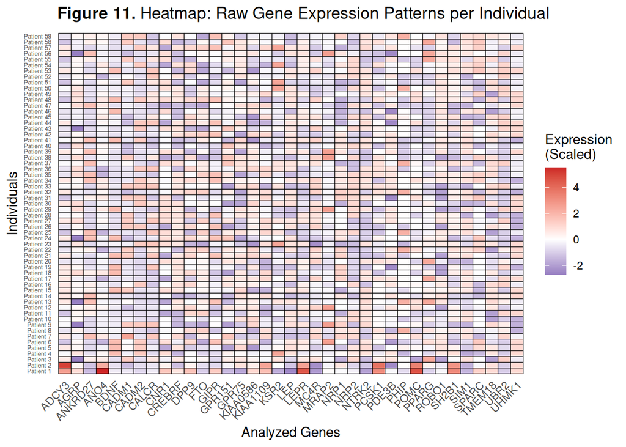

```r
heatmap_crudo
```

## 5.5 Stratified Descriptive Analysis by Tertiles

Due to the absence of multivariate and univariate normality in the distribution of gene expression variables, non-parametric statistics were chosen, reporting the median and interquartile range **($P_{25} - P_{75}$)** as measures of central tendency and dispersion. To evaluate the distribution of expression profiles within the latent space derived from principal component analysis (PCA), the sample was stratified based on the tertiles of the first three components **(PC1, PC2, and PC3)**. The analytical cut-off points corresponding to **the 33.33rd and 66.67th percentiles** were determined using the `quantile()` function, allowing precise discretization of the continuous scores. Subsequently, using the `cut()` function, each individual was assigned to an **ordinal tertile category (“t1”, “t2”, or “t3”)**. Based on this categorization, bivariate descriptive tables were developed using the `gtsummary` package, facilitating the comparison and evaluation of gene variables across the gradients of variance explained by each principal component.

```r
# Final Descriptive Table: Gene Expression by PCA Tertiles

# 1. Formatting rules configuration

# Rule for p-value: If very small (<0.001), use scientific notation;
# otherwise, show exactly 3 decimal places.
formato_p <- function(p) {
  ifelse(p < 0.001, formatC(p, format = "e", digits = 2), sprintf("%.3f", p))
}

# Auxiliary variable to generate independent "N" row without triggering NA errors
# Defined as character text so gtsummary treats it as dichotomous and performs counts only.
dataset_genes_pca$filan <- "Participants"

# 2. Calculation of tertiles (cut-off points) and categorization

# As instructed: quantile() is used for 33.33% and 66.67%,
# and cut() to label into three groups: "T1", "T2", "T3".
# Extract principal components from res_pca and assign them to the dataframe
dataset_genes_pca$PC1 <- res_pca$x[, "PC1"]
dataset_genes_pca$PC2 <- res_pca$x[, "PC2"]
dataset_genes_pca$PC3 <- res_pca$x[, "PC3"]

# Component 1 (PC1)
# - quantile(): Calculates exact cut-off points to split data into three equal
#   parts (probabilities of 0%, 33.33%, 66.67%, and 100%), omitting missing values (na.rm = TRUE).
cortes_pc1 <- quantile(dataset_genes_pca$PC1, probs = c(0, 1/3, 2/3, 1), na.rm = TRUE)
# - cut(): Converts continuous numerical PC1 into an ordinal categorical
#   variable with three levels labeled as "T1", "T2", and "T3".
dataset_genes_pca$PC1_t <- cut(dataset_genes_pca$PC1, breaks = cortes_pc1,
                               labels = c("T1", "T2", "T3"), include.lowest = TRUE)

# Component 2 (PC2): Repeat the process of calculating tertiles and categorization.
cortes_pc2 <- quantile(dataset_genes_pca$PC2, probs = c(0, 1/3, 2/3, 1), na.rm = TRUE)
dataset_genes_pca$PC2_t <- cut(dataset_genes_pca$PC2, breaks = cortes_pc2,
                               labels = c("T1", "T2", "T3"), include.lowest = TRUE)

# Component 3 (PC3): Repeat the process of calculating tertiles and categorization.
cortes_pc3 <- quantile(dataset_genes_pca$PC3, probs = c(0, 1/3, 2/3, 1), na.rm = TRUE)
dataset_genes_pca$PC3_t <- cut(dataset_genes_pca$PC3, breaks = cortes_pc3,
                               labels = c("T1", "T2", "T3"), include.lowest = TRUE)

# 3. Construction of descriptive tables per component

# --- Table for Component 1 ---
tbl_pc1 <- dataset_genes_pca %>%
  select(filan, ADCY3:UHMK1, PC1_t) %>%
  tbl_summary(
    by = PC1_t,
    # Specify variable type: dichotomous for N, continuous for genes
    type = list(filan ~ "dichotomous", ADCY3:UHMK1 ~ "continuous"),
    value = list(filan ~ "Participants"),
    # Summary statistics: count {n} for N row; median and IQR for genes
    statistic = list(filan ~ "{n}", ADCY3:UHMK1 ~ "{median} ({p25} - {p75})"),
    # Decimals: 0 for N row, 1 for genes
    digits = list(filan ~ 0, ADCY3:UHMK1 ~ 1),
    label = list(filan ~ "N"), # Label for first row
    missing = "no" # Hide missing value rows
  ) %>%
  add_p(
    include = -filan, # Exclude N row to leave p-value cell blank
    test = ADCY3:UHMK1 ~ "kruskal.test", # Non-parametric test
    pvalue_fun = formato_p
  ) %>%
  modify_header(
    all_stat_cols() ~ "**{level}**", # Column headers as T1, T2, T3
    p.value ~ "**p-value**"
  )

# --- Table for Component 2 ---
tbl_pc2 <- dataset_genes_pca %>%
  select(filan, ADCY3:UHMK1, PC2_t) %>%
  tbl_summary(
    by = PC2_t,
    type = list(filan ~ "dichotomous", ADCY3:UHMK1 ~ "continuous"),
    value = list(filan ~ "Participants"),
    statistic = list(filan ~ "{n}", ADCY3:UHMK1 ~ "{median} ({p25} - {p75})"),
    digits = list(filan ~ 0, ADCY3:UHMK1 ~ 1),
    label = list(filan ~ "N"),
    missing = "no"
  ) %>%
  add_p(
    include = -filan,
    test = ADCY3:UHMK1 ~ "kruskal.test",
    pvalue_fun = formato_p
  ) %>%
  modify_header(
    all_stat_cols() ~ "**{level}**",
    p.value ~ "**p-value**"
  )

# --- Table for Component 3 ---
tbl_pc3 <- dataset_genes_pca %>%
  select(filan, ADCY3:UHMK1, PC3_t) %>%
  tbl_summary(
    by = PC3_t,
    type = list(filan ~ "dichotomous", ADCY3:UHMK1 ~ "continuous"),
    value = list(filan ~ "Participants"),
    statistic = list(filan ~ "{n}", ADCY3:UHMK1 ~ "{median} ({p25} - {p75})"),
    digits = list(filan ~ 0, ADCY3:UHMK1 ~ 1),
    label = list(filan ~ "N"),
    missing = "no"
  ) %>%
  add_p(
    include = -filan,
    test = ADCY3:UHMK1 ~ "kruskal.test",
    pvalue_fun = formato_p
  ) %>%
  modify_header(
    all_stat_cols() ~ "**{level}**",
    p.value ~ "**p-value**"
  )

# 4. Horizontal merging and final aesthetic formatting

tabla_descriptiva_final <- tbl_merge(
  tbls = list(tbl_pc1, tbl_pc2, tbl_pc3),
  # Grouping super-headers
  tab_spanner = c("**Component 1**", "**Component 2**", "**Component 3**")
) %>%
  # Leave top-left corner blank, matching reference template
  modify_header(label = "") %>%
  # Convert to 'gt' object to insert required text headers and adjust borders
  as_gt() %>%
  gt::tab_header(
    title = gt::md("**Descriptive Table.** Stratified descriptive analysis by PCA tertiles")
  ) %>%
  gt::tab_source_note(
    source_note = gt::md("*{Insert table footnote here}*")
  ) %>%
  gt::cols_align(align = "center") %>% # Center numeric values
  gt::tab_options(
    table.border.top.color = "black",
    table.border.top.width = gt::px(2),
    table.border.bottom.color = "black",
    table.border.bottom.width = gt::px(2)
  )

# 6. Print the table

tabla_descriptiva_final
```

**Descriptive Table.** Stratified descriptive analysis by PCA tertiles

|  | **Component 1** **T1**<sup>1</sup> | **Component 1** **T2**<sup>1</sup> | **Component 1** **T3**<sup>1</sup> | **Component 1** **p-value**<sup>2</sup> | **Component 2** **T1**<sup>1</sup> | **Component 2** **T2**<sup>1</sup> | **Component 2** **T3**<sup>1</sup> | **Component 2** **p-value**<sup>2</sup> | **Component 3** **T1**<sup>1</sup> | **Component 3** **T2**<sup>1</sup> | **Component 3** **T3**<sup>1</sup> | **Component 3** **p-value**<sup>2</sup> |
| --- | --- | --- | --- | --- | --- | --- | --- | --- | --- | --- | --- | --- |
| N | 20 | 19 | 20 |  | 20 | 19 | 20 |  | 20 | 19 | 20 |  |
| ADCY3 | -0.8 (-0.9 - -0.5) | -0.5 (-0.8 - -0.2) | -0.2 (-0.8 - -0.2) | 0.016 | -0.2 (-0.8 - -0.2) | -0.5 (-0.8 - -0.2) | -0.5 (-0.8 - -0.2) | 0.490 | -0.5 (-0.9 - -0.4) | -0.5 (-0.8 - -0.2) | -0.4 (-0.8 - -0.2) | 0.351 |
| AGRP | 0.2 (-0.2 - 0.5) | 0.2 (-0.2 - 0.3) | 0.2 (-0.2 - 0.7) | 0.707 | 0.2 (-0.2 - 0.3) | 0.2 (0.2 - 0.3) | 0.2 (0.0 - 0.7) | 0.550 | 0.2 (-0.2 - 0.6) | 0.3 (0.2 - 0.7) | 0.2 (-0.2 - 0.5) | 0.657 |
| ANKRD27 | 0.8 (-0.2 - 0.8) | -0.2 (-0.4 - 2.1) | -0.4 (-0.4 - -0.2) | 0.046 | 0.3 (-0.2 - 2.1) | 0.8 (-0.4 - 0.8) | -0.4 (-0.4 - -0.2) | 0.040 | -0.2 (-0.4 - 1.5) | -0.2 (-0.4 - 0.8) | -0.2 (-0.4 - 2.1) | 0.719 |
| ANO4 | -0.5 (-0.8 - -0.3) | -0.5 (-0.5 - -0.3) | -0.3 (-0.5 - -0.2) | 0.208 | -0.5 (-0.5 - -0.3) | -0.3 (-0.5 - -0.1) | -0.5 (-0.5 - -0.3) | 0.117 | -0.5 (-0.5 - -0.3) | -0.3 (-0.5 - -0.2) | -0.5 (-0.5 - -0.2) | 0.861 |
| BDNF | -0.8 (-0.9 - -0.7) | -0.8 (-0.9 - -0.7) | -0.7 (-0.8 - 1.2) | 0.208 | -0.8 (-0.9 - -0.7) | -0.7 (-0.9 - -0.7) | -0.7 (-0.8 - 1.2) | 0.154 | -0.8 (-0.9 - 0.3) | -0.7 (-0.8 - 1.2) | -0.8 (-0.9 - -0.7) | 0.587 |
| CADM1 | -0.4 (-0.6 - 1.0) | -0.1 (-0.6 - 1.0) | -0.6 (-0.9 - -0.4) | 0.029 | -0.2 (-0.6 - 1.0) | -0.4 (-0.6 - 1.0) | -0.4 (-0.6 - -0.3) | 0.512 | -0.5 (-0.9 - 1.0) | -0.4 (-0.6 - 1.0) | -0.4 (-0.6 - -0.1) | 0.507 |
| CADM2 | -0.7 (-0.7 - -0.6) | -0.7 (-0.7 - 1.2) | -0.6 (-0.7 - 1.2) | 0.367 | -0.7 (-0.8 - -0.7) | -0.7 (-0.7 - 1.2) | 1.2 (-0.6 - 1.2) | 7.39e-05 | -0.6 (-0.7 - -0.6) | -0.7 (-0.7 - 1.2) | -0.6 (-0.7 - 1.2) | 0.399 |
| CALCR | -0.3 (-1.0 - 1.0) | -0.3 (-0.7 - 1.0) | -0.2 (-0.3 - 1.5) | 0.308 | -0.3 (-0.8 - 1.5) | -0.3 (-0.7 - 1.0) | 0.4 (-0.6 - 1.5) | 0.337 | -0.3 (-0.8 - 1.0) | -0.3 (-0.6 - 2.0) | -0.3 (-0.7 - 1.0) | 0.441 |
| CNR1 | -0.2 (-0.3 - 0.7) | -0.2 (-1.9 - 0.7) | -0.2 (-0.3 - 0.7) | 0.667 | -0.2 (-0.3 - 0.7) | -0.2 (-0.3 - 0.7) | -0.2 (-1.1 - 0.7) | 0.996 | 0.7 (-0.3 - 0.7) | -0.2 (-0.3 - 0.7) | -0.3 (-1.9 - 0.7) | 0.151 |
| CREBRF | 0.4 (-1.4 - 0.7) | 0.6 (-1.4 - 0.7) | 0.7 (-1.4 - 0.8) | 0.322 | 0.7 (0.4 - 0.8) | 0.6 (-1.4 - 0.7) | 0.1 (-1.4 - 0.8) | 0.316 | -1.4 (-1.4 - 0.7) | 0.6 (-1.4 - 0.7) | 0.7 (0.6 - 0.8) | 0.001 |
| DPP9 | -1.2 (-1.5 - -0.2) | 0.7 (-0.3 - 0.8) | -0.1 (-0.7 - 0.8) | 0.025 | 0.3 (-0.7 - 0.8) | -0.3 (-1.2 - 0.7) | -0.3 (-1.2 - 0.8) | 0.302 | -0.3 (-1.5 - 0.8) | -0.3 (-1.2 - 0.7) | 0.7 (-0.7 - 0.8) | 0.369 |
| FTO | 0.6 (0.2 - 0.9) | 0.6 (-0.3 - 0.9) | 0.6 (-0.4 - 0.9) | 0.756 | 0.9 (0.6 - 1.7) | 0.6 (-0.3 - 0.9) | -0.3 (-1.4 - 0.9) | 0.025 | 0.6 (-0.3 - 0.6) | 0.6 (-1.4 - 0.9) | 0.9 (0.8 - 1.7) | 5.46e-04 |
| GIPR | -0.4 (-0.8 - 0.0) | 0.0 (-0.2 - 1.6) | -0.2 (-0.6 - 0.7) | 0.042 | -0.2 (-0.6 - 1.5) | -0.2 (-1.0 - 0.0) | -0.2 (-0.2 - 0.0) | 0.402 | -0.2 (-0.6 - 0.0) | -0.2 (-0.6 - 0.0) | 0.0 (-0.4 - 1.6) | 0.128 |
| GPR151 | 0.4 (0.0 - 0.7) | 0.5 (-0.2 - 0.7) | -0.2 (-1.2 - 0.2) | 0.008 | 0.6 (0.3 - 1.0) | -0.2 (-1.2 - 0.5) | -0.2 (-0.7 - 0.4) | 0.002 | 0.3 (-0.2 - 0.7) | 0.1 (-1.2 - 0.5) | 0.2 (-0.2 - 0.6) | 0.481 |
| GPR75 | 0.6 (0.3 - 0.7) | 0.3 (-1.1 - 0.7) | 0.1 (-1.5 - 0.5) | 0.090 | 0.3 (-1.5 - 0.6) | 0.4 (-1.1 - 0.7) | 0.4 (-0.5 - 0.7) | 0.513 | 0.5 (-0.5 - 0.6) | 0.4 (-1.1 - 0.7) | 0.2 (-1.1 - 0.6) | 0.498 |
| KIAA0586 | 0.5 (-0.5 - 0.8) | 0.7 (-0.5 - 0.9) | 0.7 (-0.5 - 0.9) | 0.822 | 0.8 (0.5 - 0.9) | 0.7 (0.5 - 0.9) | -0.5 (-1.4 - 0.8) | 0.053 | 0.9 (0.6 - 0.9) | 0.5 (-0.5 - 0.9) | 0.3 (-0.5 - 0.7) | 0.019 |
| KIAA1109 | -0.5 (-0.7 - 0.4) | -0.5 (-0.7 - 0.3) | -0.5 (-0.7 - 0.4) | 0.830 | -0.1 (-0.5 - 0.4) | -0.5 (-0.7 - 0.3) | -0.6 (-1.6 - -0.1) | 0.028 | -0.5 (-1.1 - -0.5) | -0.5 (-0.7 - 0.4) | -0.1 (-0.7 - 0.4) | 0.250 |
| KSR2 | -0.2 (-0.6 - 0.2) | 0.0 (-0.4 - 0.6) | -0.2 (-0.8 - 0.2) | 0.570 | -0.4 (-0.8 - 0.1) | -0.2 (-0.4 - 0.0) | 0.2 (-0.4 - 2.0) | 0.041 | -0.3 (-0.8 - -0.2) | 0.0 (-0.2 - 0.6) | 0.0 (-0.4 - 0.6) | 0.027 |
| LEP | 1.0 (-0.5 - 1.1) | 1.0 (-0.7 - 1.1) | 1.0 (0.4 - 1.1) | 0.393 | -0.3 (-0.7 - 1.1) | 1.0 (-0.7 - 1.1) | 1.0 (1.0 - 1.1) | 0.022 | 1.0 (-0.7 - 1.1) | 1.0 (-0.3 - 1.1) | 1.0 (-0.5 - 1.1) | 0.525 |
| LEPR | -0.9 (-0.9 - -0.2) | -0.2 (-0.9 - 0.0) | -0.2 (-0.7 - 0.0) | 0.057 | -0.8 (-0.9 - -0.2) | -0.2 (-0.9 - 0.0) | -0.2 (-0.9 - 0.0) | 0.399 | -0.2 (-0.9 - 0.0) | -0.7 (-0.9 - 0.0) | -0.4 (-0.9 - -0.2) | 0.778 |
| MC4R | 0.5 (0.0 - 1.2) | 0.1 (0.0 - 0.9) | -0.5 (-0.5 - 0.5) | 0.039 | 0.9 (-0.2 - 1.1) | 0.1 (0.0 - 1.2) | 0.1 (-0.2 - 0.9) | 0.771 | 0.0 (-0.5 - 0.9) | 0.1 (0.0 - 1.2) | 0.5 (0.0 - 1.1) | 0.443 |
| MRAP2 | -0.2 (-0.5 - -0.2) | -0.2 (-0.5 - -0.2) | -0.2 (-0.3 - -0.1) | 0.246 | -0.2 (-0.5 - -0.2) | -0.2 (-0.5 - -0.2) | -0.3 (-0.5 - -0.2) | 0.884 | -0.2 (-0.4 - 2.4) | -0.2 (-0.5 - -0.2) | -0.3 (-0.5 - -0.2) | 0.070 |
| NRP1 | 0.7 (0.0 - 0.8) | 0.0 (0.0 - 0.7) | 0.0 (-1.6 - 1.0) | 0.674 | 0.7 (0.0 - 1.3) | 0.7 (0.0 - 0.8) | -1.2 (-1.6 - 0.4) | 0.009 | 0.3 (0.0 - 0.8) | 0.2 (-1.6 - 1.3) | 0.0 (-1.4 - 0.7) | 0.454 |
| NRP2 | 0.9 (-1.2 - 0.9) | -0.6 (-1.7 - 0.9) | -0.9 (-1.2 - 0.5) | 0.326 | -0.6 (-1.4 - 0.9) | -0.6 (-1.2 - 0.9) | -0.1 (-1.4 - 0.9) | 0.914 | -0.9 (-1.4 - 0.9) | -0.6 (-1.2 - 0.9) | 0.8 (-1.2 - 0.9) | 0.399 |
| NTRK2 | 1.1 (-0.4 - 1.1) | -0.4 (-0.6 - 1.3) | 1.1 (-0.6 - 1.1) | 0.943 | -0.4 (-0.6 - -0.4) | 1.1 (-0.6 - 1.1) | 1.1 (1.1 - 1.3) | 4.86e-05 | 1.1 (-0.5 - 1.1) | 1.1 (-0.4 - 1.1) | -0.4 (-0.6 - 1.3) | 0.907 |
| PCSK1 | -0.5 (-1.2 - -0.1) | -0.5 (-1.2 - 0.0) | -0.5 (-0.7 - -0.3) | 0.871 | -0.3 (-0.6 - 0.0) | -0.5 (-1.2 - -0.3) | -0.6 (-1.2 - -0.5) | 0.050 | -0.5 (-1.0 - -0.3) | -0.5 (-0.7 - -0.2) | -0.5 (-1.2 - 0.0) | 0.956 |
| PDE3B | 0.9 (0.3 - 0.9) | 0.3 (0.2 - 0.9) | 0.2 (-0.6 - 0.9) | 0.089 | 0.9 (0.2 - 0.9) | 0.9 (0.2 - 0.9) | 0.3 (0.2 - 0.9) | 0.448 | 0.6 (-0.5 - 0.9) | 0.9 (0.2 - 0.9) | 0.3 (0.2 - 0.9) | 0.900 |
| PHIP | 0.1 (-0.9 - 1.1) | 0.1 (-0.9 - 0.1) | 0.1 (-0.2 - 0.1) | 0.518 | 0.1 (0.1 - 1.1) | 0.1 (-0.9 - 0.1) | -0.2 (-0.9 - 0.1) | 0.019 | 0.1 (-0.9 - 0.1) | 0.1 (-0.9 - 0.1) | 0.1 (0.1 - 2.0) | 0.002 |
| POMC | -0.6 (-0.7 - -0.3) | -0.3 (-0.6 - -0.2) | -0.2 (-0.6 - 0.1) | 0.010 | -0.3 (-0.6 - -0.2) | -0.3 (-0.7 - 0.1) | -0.3 (-0.6 - -0.2) | 0.864 | -0.6 (-0.7 - -0.2) | -0.3 (-0.7 - 0.1) | -0.3 (-0.6 - -0.1) | 0.283 |
| PPARG | -0.4 (-0.8 - 1.2) | -0.4 (-1.0 - 0.1) | -1.0 (-1.1 - -0.4) | 0.064 | -0.4 (-1.0 - 0.3) | -0.4 (-1.0 - 0.1) | -0.7 (-1.1 - -0.2) | 0.258 | -0.4 (-1.0 - 0.4) | -0.4 (-1.0 - 0.1) | -0.4 (-1.0 - -0.2) | 0.510 |
| ROBO1 | 0.6 (-0.5 - 0.7) | 0.6 (0.2 - 0.8) | 0.2 (-1.3 - 0.6) | 0.158 | 0.4 (-1.3 - 0.7) | -0.5 (-2.2 - 0.8) | 0.6 (0.2 - 0.6) | 0.401 | 0.4 (-1.3 - 0.8) | 0.2 (-0.5 - 0.6) | 0.6 (0.2 - 0.8) | 0.527 |
| SH2B1 | -0.3 (-1.1 - -0.1) | -0.2 (-0.9 - -0.1) | -0.2 (-0.9 - 0.0) | 0.317 | -0.2 (-0.9 - -0.1) | -0.2 (-0.9 - -0.1) | -0.2 (-0.9 - 0.0) | 0.917 | -1.1 (-1.3 - -0.2) | -0.1 (-0.2 - 0.1) | -0.2 (-0.9 - -0.1) | 6.07e-04 |
| SIM1 | 1.2 (0.4 - 1.2) | 1.0 (-0.2 - 1.2) | 0.4 (-0.6 - 1.2) | 0.144 | 1.2 (0.4 - 1.2) | 1.0 (-0.2 - 1.2) | 0.4 (-0.7 - 1.2) | 0.155 | -0.2 (-0.2 - 1.2) | 1.0 (-0.9 - 1.2) | 1.2 (1.0 - 1.2) | 0.310 |
| SPARC | -0.1 (-0.3 - 0.0) | 0.0 (-1.2 - 1.1) | 0.0 (-0.7 - 0.9) | 0.687 | 0.0 (-0.3 - 1.1) | 0.0 (-0.2 - 0.8) | -0.3 (-1.2 - 0.8) | 0.195 | 0.0 (-0.1 - 0.9) | 0.0 (-0.2 - 0.8) | -0.3 (-1.2 - 0.4) | 0.050 |
| TMEM18 | -0.3 (-1.3 - 0.2) | 0.7 (-0.3 - 1.0) | 0.6 (-0.4 - 0.8) | 0.030 | -0.3 (-0.7 - 0.9) | -0.2 (-0.7 - 0.8) | 0.7 (-0.3 - 0.8) | 0.179 | -0.7 (-0.7 - 0.7) | 0.6 (-0.7 - 0.7) | 0.8 (-0.3 - 1.0) | 0.014 |
| UBR2 | 0.7 (-0.7 - 1.3) | 0.7 (-0.7 - 1.5) | -0.7 (-0.7 - 0.7) | 0.116 | 0.7 (-0.7 - 1.3) | 0.7 (-0.7 - 1.3) | -0.7 (-0.7 - 1.3) | 0.664 | -0.7 (-0.7 - 0.7) | 0.7 (-0.7 - 1.3) | 0.7 (-0.7 - 1.5) | 0.190 |
| UHMK1 | -0.6 (-0.7 - 0.7) | -0.7 (-2.0 - -0.6) | 0.7 (-0.6 - 0.7) | 0.022 | -0.7 (-2.0 - 0.0) | -0.6 (-0.7 - 0.7) | 0.7 (-0.6 - 0.7) | 0.032 | -0.6 (-1.4 - 0.7) | 0.7 (-0.7 - 0.7) | -0.7 (-1.4 - 0.7) | 0.309 |

## 5.6 Predictive Model (Logistic Regression)

To evaluate how the PCA results relate to overweight status, a multivariate logistic regression model was utilized. **The response variable was dichotomously defined as overweight status (coded as 1 for individuals with BMI > 25 kg/m², including overweight and obesity, and 0 for those with BMI < 25 kg/m² as the reference category)**. As **primary predictor variables, the ordinal categories corresponding to the principal component tertiles obtained from the principal component analysis (PCA) were incorporated**. Additionally, **clinical adjustment covariates (edad_anios, sexo, glucosa_mg_dl, tg_mg_dl, colesterol_total_mg_dl, ldl_mg_dl, hdl_mg_dl, pas_mmhg, pad_mmhg, albumina_g_dl, ast_u_l, alt_u_l, fosfatasa_alcalina_u_l, urea_mg_dl)** were included to control for potential confounding biases. Finally, to analyze and interpret the effect of each variable, key statistical parameters were extracted: **exponentiated coefficients (Odds Ratios or OR), 95% confidence intervals, and p-values**.

```r
# 1. Preparation and cleaning of variables

# A) Outcome Variable (Dependent): Overweight
# Create a binary variable: 1 if BMI >= 25 (overweight/obesity), 0 if BMI < 25 (normal weight)
# - imc_kg_m2: Original body mass index from the dataset.
# - ifelse(): Evaluates condition by condition. If BMI is greater than or equal to 25,
#   assigns 1 (classified as overweight/obesity); otherwise, assigns 0
#   (normal weight/underweight), following standard clinical criteria.
gensimpson_limpio$sobrepeso <- ifelse(gensimpson_limpio$imc_kg_m2 >= 25, 1, 0)

# B) Sociodemographic Adjustment Variables
# - as.factor(): Converts text or numeric variable into a categorical factor.
gensimpson_limpio$sexo <- as.factor(gensimpson_limpio$sexo)
# - relevel(): Modifies factor category order to explicitly set
#   "Masculino" as the reference category in the statistical model.
gensimpson_limpio$sexo <- relevel(gensimpson_limpio$sexo, ref = "Masculino")

# C) Categorical Clinical Variables
gensimpson_limpio$enfermedades <- as.factor(gensimpson_limpio$enfermedades)
gensimpson_limpio$medicamento <- as.factor(gensimpson_limpio$medicamento)


# 2. Predictor variables (Principal Component Tertiles - PCA)

# - apply(): Applies a function across margins of an array or data frame.
# - scores_pca: Matrix containing individual coordinates across principal components.
# - quantile(..., probs = c(1/3, 2/3)): Calculates 33.33% and 66.67% percentiles
#   to split each principal component into three equal parts.
terciles_generales <- apply(scores_pca, 2, quantile, probs = c(1/3, 2/3))

# Add numeric scores to the main data frame
gensimpson_limpio$PC1 <- scores_pca[, "PC1"]
gensimpson_limpio$PC2 <- scores_pca[, "PC2"]
gensimpson_limpio$PC3 <- scores_pca[, "PC3"]

# Categorize the three principal components into tertiles (T1 as reference category)

# - cut(): Divides a continuous numeric vector into discrete intervals.
# - breaks: Defines limits using previously calculated cut points (-Inf to Inf).
# - labels: Assigns categorical labels "T1", "T2", and "T3" (T1 being reference tertile).
gensimpson_limpio$PC1_cat <- cut(gensimpson_limpio$PC1,
                                 breaks = c(-Inf, terciles_generales[1, "PC1"], terciles_generales[2, "PC1"], Inf),
                                 labels = c("T1", "T2", "T3"))

gensimpson_limpio$PC2_cat <- cut(gensimpson_limpio$PC2,
                                 breaks = c(-Inf, terciles_generales[1, "PC2"], terciles_generales[2, "PC2"], Inf),
                                 labels = c("T1", "T2", "T3"))

gensimpson_limpio$PC3_cat <- cut(gensimpson_limpio$PC3,
                                 breaks = c(-Inf, terciles_generales[1, "PC3"], terciles_generales[2, "PC3"], Inf),
                                 labels = c("T1", "T2", "T3"))


# 3. Multivariate Logistic Regression Model

# - glm(): Fits generalized linear models.
# - family = binomial: Specifies a binomial distribution, transforming
#   the model into a standard logistic regression for a binary outcome (0/1).
# Methodological note: Creatinine and bilirubin were excluded from this version
# due to prior collinearity issues and mathematical instability.
modelo <- glm(sobrepeso ~ PC1_cat + PC2_cat + PC3_cat +
                edad_anios + sexo +
                glucosa_mg_dl + tg_mg_dl + colesterol_total_mg_dl + ldl_mg_dl + hdl_mg_dl +
                pas_mmhg + pad_mmhg +
                albumina_g_dl + ast_u_l + alt_u_l + fosfatasa_alcalina_u_l + urea_mg_dl,
              data = gensimpson_limpio,
              family = binomial)

# 4. Model quality and goodness-of-fit evaluation

# cat("=== Summary and quality of logistic model ===\n")
# cat("\nModel AIC:", AIC(modelo), "\n")
# cat("Null deviance:", modelo$null.deviance, "| Residual deviance:", modelo$deviance, "\n")

# 5. Functions for Extraction and Formatting of Statistical Parameters

# A) Extraction of exponentiated estimates (Odds Ratios - OR)
estimaciones_or <- exp(coef(modelo))
# B) Extraction of 95% confidence intervals for ORs
intervalos_ic <- suppressMessages(exp(confint(modelo)))
# C) Extraction of p-values for model terms
p_valores <- summary(modelo)$coefficients[, "Pr(>|z|)"]
# D) Custom function to combine Odds Ratio and 95% CI into a single formatted text cell
formatear_celda <- function(nombre_variable) {
  or <- estimaciones_or[nombre_variable]
  ic_inf <- intervalos_ic[nombre_variable, 1]
  ic_sup <- intervalos_ic[nombre_variable, 2]
  sprintf("%.1f (%.1f to %.1f)", or, ic_inf, ic_sup) # Style: "OR (Inf to Sup)" with 1 decimal
}
# E) Custom function for strict p-value formatting
formatear_pvalue <- function(nombre_variable) {
  pval <- p_valores[nombre_variable]
  if (pval < 0.001) return("<0.001") else return(sprintf("%.3f", pval))
}

# 6. Automated parameter extraction for each variable

# --- Principal Components ---
celda_T2_OR_PC1 <- formatear_celda("PC1_catT2"); celda_T2_P_PC1 <- formatear_pvalue("PC1_catT2")
celda_T3_OR_PC1 <- formatear_celda("PC1_catT3"); celda_T3_P_PC1 <- formatear_pvalue("PC1_catT3")

celda_T2_OR_PC2 <- formatear_celda("PC2_catT2"); celda_T2_P_PC2 <- formatear_pvalue("PC2_catT2")
celda_T3_OR_PC2 <- formatear_celda("PC2_catT3"); celda_T3_P_PC2 <- formatear_pvalue("PC2_catT3")

celda_T2_OR_PC3 <- formatear_celda("PC3_catT2"); celda_T2_P_PC3 <- formatear_pvalue("PC3_catT3")
celda_T3_OR_PC3 <- formatear_celda("PC3_catT3"); celda_T3_P_PC3 <- formatear_pvalue("PC3_catT3")

# --- Adjustment Covariates ---
celda_edad_OR      <- formatear_celda("edad_anios");            celda_edad_P      <- formatear_pvalue("edad_anios")
celda_sexo_OR      <- formatear_celda("sexoFemenino");          celda_sexo_P      <- formatear_pvalue("sexoFemenino")
celda_glucosa_OR   <- formatear_celda("glucosa_mg_dl");       celda_glucosa_P   <- formatear_pvalue("glucosa_mg_dl")
celda_tg_OR        <- formatear_celda("tg_mg_dl");            celda_tg_P        <- formatear_pvalue("tg_mg_dl")
celda_col_OR       <- formatear_celda("colesterol_total_mg_dl"); celda_col_P     <- formatear_pvalue("colesterol_total_mg_dl")
celda_ldl_OR       <- formatear_celda("ldl_mg_dl");           celda_ldl_P       <- formatear_pvalue("ldl_mg_dl")
celda_hdl_OR       <- formatear_celda("hdl_mg_dl");           celda_hdl_P       <- formatear_pvalue("hdl_mg_dl")
celda_pas_OR       <- formatear_celda("pas_mmhg");            celda_pas_P       <- formatear_pvalue("pas_mmhg")
celda_pad_OR       <- formatear_celda("pad_mmhg");            celda_pad_P       <- formatear_pvalue("pad_mmhg")
celda_albumina_OR  <- formatear_celda("albumina_g_dl");          celda_albumina_P  <- formatear_pvalue("albumina_g_dl")
celda_ast_OR       <- formatear_celda("ast_u_l");               celda_ast_P       <- formatear_pvalue("ast_u_l")
celda_alt_OR       <- formatear_celda("alt_u_l");               celda_alt_P       <- formatear_pvalue("alt_u_l")
celda_fosfatasa_OR <- formatear_celda("fosfatasa_alcalina_u_l"); celda_fosfatasa_P <- formatear_pvalue("fosfatasa_alcalina_u_l")
celda_urea_OR      <- formatear_celda("urea_mg_dl");            celda_urea_P      <- formatear_pvalue("urea_mg_dl")
```

```r
# 7. Construction of the final results table

tabla_df <- data.frame(
  Variable = c(
    "Component 1 tertiles",
    "Component 2 tertiles",
    "Component 3 tertiles",
    "Age (years)",
    "Sex (Female vs Male)",
    "Glucose (mg/dL)",
    "Triglycerides (mg/dL)",
    "Total cholesterol (mg/dL)",
    "LDL (mg/dL)",
    "HDL (mg/dL)",
    "Systolic blood pressure (mmHg)",
    "Diastolic blood pressure (mmHg)",
    "Albumin (g/dL)",
    "AST (U/L)",
    "ALT (U/L)",
    "Alkaline phosphatase (U/L)",
    "Urea (mg/dL)"
  ),

  # T1 Column (Reference)
  T1_OR = c("1 (Ref.)", "1 (Ref.)", "1 (Ref.)",
            celda_edad_OR, celda_sexo_OR, celda_glucosa_OR,
            celda_tg_OR, celda_col_OR, celda_ldl_OR,
            celda_hdl_OR, celda_pas_OR, celda_pad_OR,
            celda_albumina_OR, celda_ast_OR, celda_alt_OR,
            celda_fosfatasa_OR, celda_urea_OR),
  T1_P  = c("NA", "NA", "NA",
            celda_edad_P, celda_sexo_P, celda_glucosa_P,
            celda_tg_P, celda_col_P, celda_ldl_P,
            celda_hdl_P, celda_pas_P, celda_pad_P,
            celda_albumina_P, celda_ast_P, celda_alt_P,
            celda_fosfatasa_P, celda_urea_P),

  # T2 Column
  T2_OR = c(celda_T2_OR_PC1, celda_T2_OR_PC2, celda_T2_OR_PC3,
            celda_edad_OR, celda_sexo_OR, celda_glucosa_OR,
            celda_tg_OR, celda_col_OR, celda_ldl_OR,
            celda_hdl_OR, celda_pas_OR, celda_pad_OR,
            celda_albumina_OR, celda_ast_OR, celda_alt_OR,
            celda_fosfatasa_OR, celda_urea_OR),
  T2_P  = c(celda_T2_P_PC1, celda_T2_P_PC2, celda_T2_P_PC3,
            celda_edad_P, celda_sexo_P, celda_glucosa_P,
            celda_tg_P, celda_col_P, celda_ldl_P,
            celda_hdl_P, celda_pas_P, celda_pad_P,
            celda_albumina_P, celda_ast_P, celda_alt_P,
            celda_fosfatasa_P, celda_urea_P),

  # T3 Column
  T3_OR = c(celda_T3_OR_PC1, celda_T3_OR_PC2, celda_T3_OR_PC3,
            celda_edad_OR, celda_sexo_OR, celda_glucosa_OR,
            celda_tg_OR, celda_col_OR, celda_ldl_OR,
            celda_hdl_OR, celda_pas_OR, celda_pad_OR,
            celda_albumina_OR, celda_ast_OR, celda_alt_OR,
            celda_fosfatasa_OR, celda_urea_OR),
  T3_P  = c(celda_T3_P_PC1, celda_T3_P_PC2, celda_T3_P_PC3,
            celda_edad_P, celda_sexo_P, celda_glucosa_P,
            celda_tg_P, celda_col_P, celda_ldl_P,
            celda_hdl_P, celda_pas_P, celda_pad_P,
            celda_albumina_P, celda_ast_P, celda_alt_P,
            celda_fosfatasa_P, celda_urea_P),

  stringsAsFactors = FALSE
)

# Set clean column headers
colnames(tabla_df) <- c("", "OR (95% CI)", "P value", "OR (95% CI)", "P value", "OR (95% CI)", "P value")

# Render and format table using kable and kableExtra
tabla_regresion <- kable(tabla_df, format = "html", align = "lcccccc", escape = FALSE) %>%
  kable_styling(bootstrap_options = c("striped", "hover", "bordered", "condensed"), full_width = FALSE) %>%
  add_header_above(c(" " = 1, "T1" = 2, "T2" = 2, "T3" = 2), bold = TRUE) %>%
  add_header_above(c("Logistic Regression Table. Multivariate Risk of Overweight" = 7),
                   align = "l", font_size = "large", bold = TRUE, background = "white") %>%
  footnote(general = "Note: Multivariate logistic regression model evaluating the risk of overweight (BMI >= 25 kg/m^2). The main predictor variables correspond to the tertiles (T1, T2, T3) of the principal components (PC1, PC2, PC3) from genetic PCA, with T1 as the reference category. The model was simultaneously adjusted for age, sex, biochemical profile, blood pressure, and selected liver/kidney function tests. Odds Ratios (OR) express adjusted associations.",
           general_title = "")


# 8. Generation of quality and statistical summary tables

# A) Detailed table of log coefficients (Betas and z-tests)

coef_df <- as.data.frame(summary(modelo)$coefficients)
colnames(coef_df) <- c("Estimate (β)", "Standard Error", "z Statistic", "P value")
coef_df$`Estimate (β)` <- sprintf("%.3f", coef_df$`Estimate (β)`)
coef_df$`Standard Error` <- sprintf("%.3f", coef_df$`Standard Error`)
coef_df$`z Statistic` <- sprintf("%.3f", coef_df$`z Statistic`)
coef_df$`P value` <- ifelse(as.numeric(coef_df$`P value`) < 0.001, "<0.001", sprintf("%.3f", as.numeric(coef_df$`P value`)))

tabla_coeficientes <- kable(coef_df, format = "html", align = "lcccc", escape = FALSE) %>%
  kable_styling(bootstrap_options = c("striped", "hover", "bordered", "condensed"), full_width = FALSE) %>%
  row_spec(0, bold = TRUE, background = "#f2f2f2") %>%
  add_header_above(c("Statistical Summary of Logistic Model Coefficients" = 5),
                   align = "l", font_size = "large", bold = TRUE, background = "white")

# B) Overall Goodness-of-Fit Table (AIC and Deviances)
calidad_df <- data.frame(
  Metrica = c(
    "Akaike Information Criterion (AIC)",
    "Null Deviance",
    "Residual Deviance",
    "Residual degrees of freedom",
    "Analyzed sample size (N)"
  ),
  Valor = c(
    sprintf("%.2f", AIC(modelo)),
    sprintf("%.2f", modelo$null.deviance),
    sprintf("%.2f", modelo$deviance),
    modelo$df.residual,
    length(modelo$y)
  ),
  stringsAsFactors = FALSE
)

colnames(calidad_df) <- c("Global Fit Metric", "Statistical Value")

tabla_calidad <- kable(calidad_df, format = "html", align = "lc", escape = FALSE) %>%
  kable_styling(bootstrap_options = c("striped", "hover", "bordered", "condensed"), full_width = FALSE) %>%
  row_spec(0, bold = TRUE, background = "#f2f2f2") %>%
  add_header_above(c("Model Quality and Goodness-of-Fit Evaluation" = 2),
                   align = "l", font_size = "large", bold = TRUE, background = "white") %>%
  footnote(general = "Note: A lower AIC value indicates a better balance of parsimony. The difference between null and residual deviance evaluates overall explanatory power.",
           general_title = "")

# 9. Table visualization

tabla_regresion
```

[output not shown]

Note: Multivariate logistic regression model evaluating the risk of overweight (BMI >= 25 kg/m^2). The main predictor variables correspond to the tertiles (T1, T2, T3) of the principal components (PC1, PC2, PC3) from genetic PCA, with T1 as the reference category. The model was simultaneously adjusted for age, sex, biochemical profile, blood pressure, and selected liver/kidney function tests. Odds Ratios (OR) express adjusted associations.

```r
tabla_coeficientes
```

| Statistical Summary of Logistic Model Coefficients | Statistical Summary of Logistic Model Coefficients Estimate (β) | Statistical Summary of Logistic Model Coefficients Standard Error | Statistical Summary of Logistic Model Coefficients z Statistic | Statistical Summary of Logistic Model Coefficients P value |
| --- | --- | --- | --- | --- |
| (Intercept) | -9.867 | 18.762 | -0.526 | 0.599 |
| PC1_catT2 | 0.093 | 1.033 | 0.090 | 0.928 |
| PC1_catT3 | 0.992 | 1.263 | 0.786 | 0.432 |
| PC2_catT2 | -1.519 | 1.162 | -1.308 | 0.191 |
| PC2_catT3 | -3.119 | 1.572 | -1.984 | 0.047 |
| PC3_catT2 | 0.940 | 1.079 | 0.871 | 0.384 |
| PC3_catT3 | -0.395 | 1.184 | -0.334 | 0.739 |
| edad_anios | 0.041 | 0.037 | 1.113 | 0.266 |
| sexoFemenino | -0.043 | 1.381 | -0.031 | 0.975 |
| glucosa_mg_dl | 0.151 | 0.134 | 1.126 | 0.260 |
| tg_mg_dl | -0.027 | 0.069 | -0.397 | 0.691 |
| colesterol_total_mg_dl | 0.144 | 0.119 | 1.208 | 0.227 |
| ldl_mg_dl | -0.208 | 0.111 | -1.870 | 0.061 |
| hdl_mg_dl | 0.193 | 0.139 | 1.389 | 0.165 |
| pas_mmhg | -0.007 | 0.055 | -0.122 | 0.903 |
| pad_mmhg | 0.028 | 0.070 | 0.400 | 0.689 |
| albumina_g_dl | -5.934 | 3.642 | -1.629 | 0.103 |
| ast_u_l | -0.170 | 0.423 | -0.401 | 0.688 |
| alt_u_l | 0.228 | 0.351 | 0.651 | 0.515 |
| fosfatasa_alcalina_u_l | 0.096 | 0.100 | 0.964 | 0.335 |
| urea_mg_dl | -0.101 | 0.146 | -0.690 | 0.490 |

```r
tabla_calidad
```

| Model Quality and Goodness-of-Fit Evaluation Global Fit Metric | Model Quality and Goodness-of-Fit Evaluation Statistical Value |
| --- | --- |
| Akaike Information Criterion (AIC) | 90.30 |
| Null Deviance | 81.37 |
| Residual Deviance | 48.30 |
| Residual degrees of freedom | 38 |
| Analyzed sample size (N) | 59 |

Note: A lower AIC value indicates a better balance of parsimony. The difference between null and residual deviance evaluates overall explanatory power.

Plot of the logistic regression analysis results for the OR variables

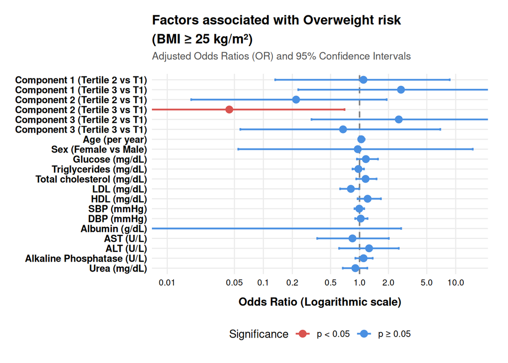

```r
# STEP 1: Structured extraction of regression model parameters

# Create a data frame extracting regression coefficients from the 'modelo' object.
# Since 'modelo' comes from a glm(..., family = binomial), the original coefficients
# are on the log-odds scale (\beta), so we apply exp() to
# obtain Odds Ratios (OR) and their confidence intervals.

datos_forest <- data.frame(
  # Extract the names of each term/independent variable from the model
  Variable_raw = names(coef(modelo)),

  # Transform \beta coefficients to Odds Ratios: OR = exp(\beta)
  OR = exp(coef(modelo)),

  # Calculate 95% confidence intervals based on profile likelihood
  # and exponentiate them. [, 1] extracts the lower bound (2.5%)
  IC_lower = suppressMessages(exp(confint(modelo)))[, 1],

  # [, 2] extracts the upper bound of the confidence interval (97.5%)
  IC_upper = suppressMessages(exp(confint(modelo)))[, 2],

  # Extract the p-values column (Pr(>|z|)) from the coefficients table
  P_value = summary(modelo)$coefficients[, "Pr(>|z|)"]
)


# STEP 2: Cleaning, recoding labels, and significance categorization

datos_forest <- datos_forest %>%
  # Exclude the intercept (\beta_0) since it does not represent a predictor variable of interest
  filter(Variable_raw != "(Intercept)") %>%

  # Create columns for human-readable labels and statistical classification
  mutate(
    # Mapping internal R names to formal publication labels
    Etiqueta = case_when(
      Variable_raw == "PC1_catT2" ~ "Component 1 (Tertile 2 vs T1)",
      Variable_raw == "PC1_catT3" ~ "Component 1 (Tertile 3 vs T1)",
      Variable_raw == "PC2_catT2" ~ "Component 2 (Tertile 2 vs T1)",
      Variable_raw == "PC2_catT3" ~ "Component 2 (Tertile 3 vs T1)",
      Variable_raw == "PC3_catT2" ~ "Component 3 (Tertile 2 vs T1)",
      Variable_raw == "PC3_catT3" ~ "Component 3 (Tertile 3 vs T1)",
      Variable_raw == "edad_anios" ~ "Age (per year)",
      Variable_raw == "sexoFemenino" ~ "Sex (Female vs Male)",
      Variable_raw == "glucosa_mg_dl" ~ "Glucose (mg/dL)",
      Variable_raw == "tg_mg_dl" ~ "Triglycerides (mg/dL)",
      Variable_raw == "colesterol_total_mg_dl" ~ "Total cholesterol (mg/dL)",
      Variable_raw == "ldl_mg_dl" ~ "LDL (mg/dL)",
      Variable_raw == "hdl_mg_dl" ~ "HDL (mg/dL)",
      Variable_raw == "pas_mmhg" ~ "SBP (mmHg)",
      Variable_raw == "pad_mmhg" ~ "DBP (mmHg)",
      Variable_raw == "albumina_g_dl" ~ "Albumin (g/dL)",
      Variable_raw == "ast_u_l" ~ "AST (U/L)",
      Variable_raw == "alt_u_l" ~ "ALT (U/L)",
      Variable_raw == "fosfatasa_alcalina_u_l" ~ "Alkaline Phosphatase (U/L)",
      Variable_raw == "urea_mg_dl" ~ "Urea (mg/dL)",
      TRUE ~ Variable_raw  # Keeps original name if any variable does not match
    ),

    # Dichotomous variable to assign color code based on threshold \alpha = 0.05
    Significativo = ifelse(P_value < 0.05, "p < 0.05", "p ≥ 0.05")
  )

# Convert 'Etiqueta' column to factor with reversed order rev().
# This ensures ggplot2 displays variables top-to-bottom
# in the exact order they were entered into the model formula.
datos_forest$Etiqueta <- factor(datos_forest$Etiqueta, levels = rev(datos_forest$Etiqueta))


# STEP 3: Construction of graphic layer using ggplot2

# Main aesthetic definition: X is OR magnitude, Y are variables,
# and element color depends on statistical significance.
grafica_or <- ggplot(datos_forest, aes(x = OR, y = Etiqueta, color = Significativo)) +

  # Vertical reference line at OR = 1 (Null value: neither risk nor protection)
  geom_vline(xintercept = 1, linetype = "dashed", color = "gray50", size = 0.7) +

  # Draw horizontal error bars for 95% CI (xmin to xmax)
  geom_errorbarh(aes(xmin = IC_lower, xmax = IC_upper), height = 0.25, size = 0.8) +

  # Draw point estimate of Odds Ratio as a central point
  geom_point(size = 3) +

  # Set X-axis scale to logarithmic scale (biostatistical standard for OR).
  # Explicitly define breaks and label text format
  scale_x_log10(
    breaks = c(0.01, 0.05, 0.1, 0.2, 0.5, 1.0, 2.0, 5.0, 10.0),
    labels = c("0.01", "0.05", "0.1", "0.2", "0.5", "1.0", "2.0", "5.0", "10.0")
  ) +

  # Expand visible area limits without cropping points falling at low values
  # (e.g. OR < 0.1), preventing ggplot2 from hiding out-of-range elements.
  coord_cartesian(xlim = c(0.01, 15.0)) +

  # Manual assignment of corporate/academic colors (Red for significant, Blue for non-significant)
  scale_color_manual(values = c("p < 0.05" = "#D9534F", "p ≥ 0.05" = "#4A90E2")) +

  # Titles, subtitles, and axis labels (using \n for line break in title)
  labs(
    title = "Factors associated with Overweight risk\n(BMI ≥ 25 kg/m²)",
    subtitle = "Adjusted Odds Ratios (OR) and 95% Confidence Intervals",
    x = "Odds Ratio (Logarithmic scale)",
    y = NULL,
    color = "Significance"
  ) +

  # STEP 4: Aesthetic customization of visual theme

  theme_minimal(base_size = 11) +
  theme(
    # Main title format (bold and line spacing)
    plot.title = element_text(face = "bold", size = 13, hjust = 0, lineheight = 1.2),

    # Subtitle format
    plot.subtitle = element_text(size = 10, color = "gray30", margin = margin(b = 12)),

    # Y-axis labels style (variable names in bold)
    axis.text.y = element_text(face = "bold", color = "black", size = 9.5),

    # X-axis values style
    axis.text.x = element_text(color = "black", size = 8.5),

    # X-axis title style
    axis.title.x = element_text(face = "bold", margin = margin(t = 10)),

    # Legend position at the bottom
    legend.position = "bottom",

    # Removal of unnecessary minor grid lines to clean plot
    panel.grid.minor = element_blank(),
    panel.grid.major.y = element_line(color = "gray92"),

    # Outer canvas margins (top, right, bottom, left) in points
    plot.margin = margin(t = 15, r = 20, b = 15, l = 15)
  )

# Display OR plot
grafica_or
```

# 6 Results

## 6.1 Normality Evaluation of Gene Expression

Based on the Shapiro-Wilk test results, the $p$-values obtained for the gene expression variables are lower than the established significance level ($\text{p-value} < 0.05$). This indicates that the data fall outside the 95% confidence interval defined by the theoretical Gaussian distribution curve. Therefore, the null hypothesis ($H_0$) is rejected, formally concluding that the expression data do not follow a normal distribution. This finding methodologically justifies the use of non-parametric statistics (such as the median and interquartile range) throughout the analysis, as shown in Model Table 1.

```r
tabla_1
```

**Model Table 1.** Gene expression normality analysis

| Variable | Test used | p-value | Interpretation |
| --- | --- | --- | --- |
| ADCY3 | Shapiro-Wilk | 1.1e-08 | Non-normal |
| AGRP | Shapiro-Wilk | 1.3e-09 | Non-normal |
| ANKRD27 | Shapiro-Wilk | 6.5e-08 | Non-normal |
| ANO4 | Shapiro-Wilk | 8.0e-10 | Non-normal |
| BDNF | Shapiro-Wilk | 2.8e-11 | Non-normal |
| CADM1 | Shapiro-Wilk | 3.1e-06 | Non-normal |
| CADM2 | Shapiro-Wilk | 8.4e-11 | Non-normal |
| CALCR | Shapiro-Wilk | 8.7e-07 | Non-normal |
| CNR1 | Shapiro-Wilk | 2.5e-07 | Non-normal |
| CREBRF | Shapiro-Wilk | 8.4e-10 | Non-normal |
| DPP9 | Shapiro-Wilk | 4.6e-06 | Non-normal |
| FTO | Shapiro-Wilk | 7.5e-06 | Non-normal |
| GIPR | Shapiro-Wilk | 2.5e-07 | Non-normal |
| GPR151 | Shapiro-Wilk | 0.000 | Non-normal |
| GPR75 | Shapiro-Wilk | 8.7e-08 | Non-normal |
| KIAA0586 | Shapiro-Wilk | 4.6e-06 | Non-normal |
| KIAA1109 | Shapiro-Wilk | 7.7e-05 | Non-normal |
| KSR2 | Shapiro-Wilk | 1.1e-06 | Non-normal |
| LEP | Shapiro-Wilk | 2.1e-09 | Non-normal |
| LEPR | Shapiro-Wilk | 8.9e-08 | Non-normal |
| MC4R | Shapiro-Wilk | 4.5e-05 | Non-normal |
| MRAP2 | Shapiro-Wilk | 1.0e-11 | Non-normal |
| NRP1 | Shapiro-Wilk | 2.6e-06 | Non-normal |
| NRP2 | Shapiro-Wilk | 7.2e-08 | Non-normal |
| NTRK2 | Shapiro-Wilk | 1.0e-08 | Non-normal |
| PCSK1 | Shapiro-Wilk | 2.3e-06 | Non-normal |
| PDE3B | Shapiro-Wilk | 1.4e-09 | Non-normal |
| PHIP | Shapiro-Wilk | 1.2e-07 | Non-normal |
| POMC | Shapiro-Wilk | 3.6e-08 | Non-normal |
| PPARG | Shapiro-Wilk | 3.4e-08 | Non-normal |
| ROBO1 | Shapiro-Wilk | 1.7e-09 | Non-normal |
| SH2B1 | Shapiro-Wilk | 3.6e-06 | Non-normal |
| SIM1 | Shapiro-Wilk | 8.9e-09 | Non-normal |
| SPARC | Shapiro-Wilk | 2.7e-05 | Non-normal |
| TMEM18 | Shapiro-Wilk | 1.1e-06 | Non-normal |
| UBR2 | Shapiro-Wilk | 1.5e-08 | Non-normal |
| UHMK1 | Shapiro-Wilk | 2.7e-07 | Non-normal |

Note: N=59. The Shapiro-Wilk statistical test was applied. A p-value < 0.05 assumes a Non-normal distribution.

## 6.2 Dimensionality Reduction and Variance (PCA)

Principal Component Analysis (PCA) enabled the exploration of the multivariate structure of the dataset, initially revealing in the PCA Components and $R^2$ Table that variance retention is distributed in a decreasing manner, where the first principal component (PC1) captures 12.48% of the biological variability and PC2 captures 8.56%. This indicates that the sample is highly heterogeneous and that the patients’ genetic profiles depend on multiple simultaneous metabolic pathways rather than a single dominant marker. To determine exactly which genes drive this variability along each of these axes, the PCA Loadings Table provides evidence that in PC1, the *POMC* (0.373) and *ANO4* (0.364) genes make positive contributions, while the *MC4R* gene (-0.225) exerts the strongest negative influence along that same dimension.

```r
tabla_modelo_pca
```

**PCA Table: Components and R².** Variance explained by the first 6 components

| Componente | R² |
| --- | --- |
| PC1 | 12.48% |
| PC2 | 8.56% |
| PC3 | 6.53% |
| PC4 | 6.13% |
| PC5 | 5.36% |
| PC6 | 4.89% |

R² values represent the percentage of variance retained by each principal component

```r
tabla_modelo_cargas
```

**PCA Loadings Table.** Factor loadings of gene variables across principal components

| Variable | PC1 | PC2 | PC3 | PC4 | PC5 | PC6 |
| --- | --- | --- | --- | --- | --- | --- |
| ADCY3 | 0.331 | −0.086 | 0.095 | −0.095 | 0.058 | −0.067 |
| AGRP | 0.066 | 0.090 | 0.103 | 0.214 | −0.221 | −0.216 |
| ANKRD27 | −0.149 | −0.172 | 0.012 | −0.304 | 0.060 | 0.064 |
| ANO4 | 0.364 | −0.030 | 0.026 | 0.040 | −0.103 | −0.128 |
| BDNF | 0.004 | 0.184 | −0.094 | 0.092 | 0.292 | −0.236 |
| CADM1 | −0.085 | −0.083 | −0.061 | 0.219 | −0.224 | 0.293 |
| CADM2 | −0.009 | 0.326 | 0.052 | 0.177 | 0.155 | 0.232 |
| CALCR | −0.004 | 0.051 | 0.079 | 0.220 | −0.180 | 0.181 |
| CNR1 | 0.090 | −0.041 | −0.118 | −0.191 | −0.148 | −0.011 |
| CREBRF | 0.005 | −0.104 | 0.329 | 0.068 | 0.149 | 0.114 |
| DPP9 | 0.142 | −0.052 | 0.089 | 0.285 | 0.367 | −0.076 |
| FTO | −0.086 | −0.249 | 0.303 | −0.047 | 0.202 | −0.103 |
| GIPR | 0.083 | 0.068 | 0.134 | 0.077 | 0.363 | 0.384 |
| GPR151 | −0.132 | −0.210 | −0.060 | −0.180 | −0.084 | −0.017 |
| GPR75 | −0.117 | 0.074 | −0.098 | −0.039 | 0.019 | −0.336 |
| KIAA0586 | 0.054 | −0.247 | −0.261 | 0.161 | −0.089 | 0.171 |
| KIAA1109 | 0.171 | −0.139 | 0.168 | −0.111 | −0.172 | 0.191 |
| KSR2 | −0.066 | 0.260 | 0.191 | −0.134 | −0.191 | 0.186 |
| LEP | −0.147 | 0.228 | 0.094 | −0.131 | 0.223 | 0.006 |
| LEPR | 0.335 | 0.058 | −0.072 | −0.164 | 0.014 | −0.095 |
| MC4R | −0.225 | −0.147 | 0.088 | 0.299 | 0.012 | −0.182 |
| MRAP2 | 0.017 | −0.016 | −0.422 | 0.028 | 0.118 | −0.045 |
| NRP1 | 0.000 | −0.278 | −0.138 | 0.078 | 0.073 | 0.176 |
| NRP2 | −0.087 | −0.050 | 0.116 | 0.140 | −0.208 | −0.272 |
| NTRK2 | −0.145 | 0.335 | −0.027 | −0.107 | −0.002 | −0.031 |
| PCSK1 | 0.292 | −0.136 | −0.019 | −0.063 | −0.039 | 0.072 |
| PDE3B | −0.153 | −0.042 | 0.192 | 0.126 | −0.268 | 0.109 |
| PHIP | −0.060 | −0.250 | 0.253 | −0.168 | 0.109 | −0.009 |
| POMC | 0.373 | −0.039 | 0.065 | −0.014 | 0.028 | −0.003 |
| PPARG | −0.078 | −0.108 | −0.164 | −0.271 | 0.089 | 0.043 |
| ROBO1 | −0.054 | 0.166 | 0.130 | −0.418 | −0.067 | 0.124 |
| SH2B1 | 0.269 | −0.011 | 0.232 | −0.047 | −0.060 | −0.182 |
| SIM1 | −0.151 | −0.186 | 0.139 | −0.058 | 0.250 | −0.116 |
| SPARC | 0.066 | −0.019 | −0.244 | −0.029 | 0.137 | 0.204 |
| TMEM18 | 0.130 | 0.200 | 0.187 | 0.087 | 0.013 | 0.121 |
| UBR2 | −0.119 | −0.101 | 0.149 | −0.071 | −0.097 | −0.054 |
| UHMK1 | 0.094 | 0.215 | −0.018 | −0.085 | −0.058 | −0.142 |

*Note: Values show the contribution and correlation of each gene with respect to the principal components.*

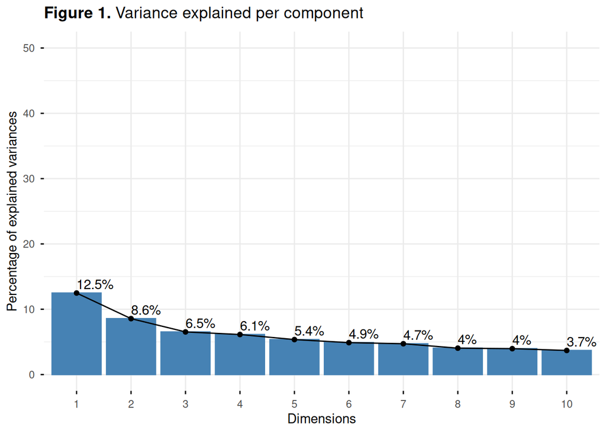

```r
grafico_varianza
```

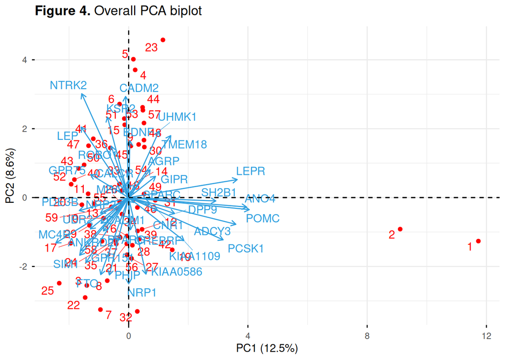

```r
grafico_biplot
```

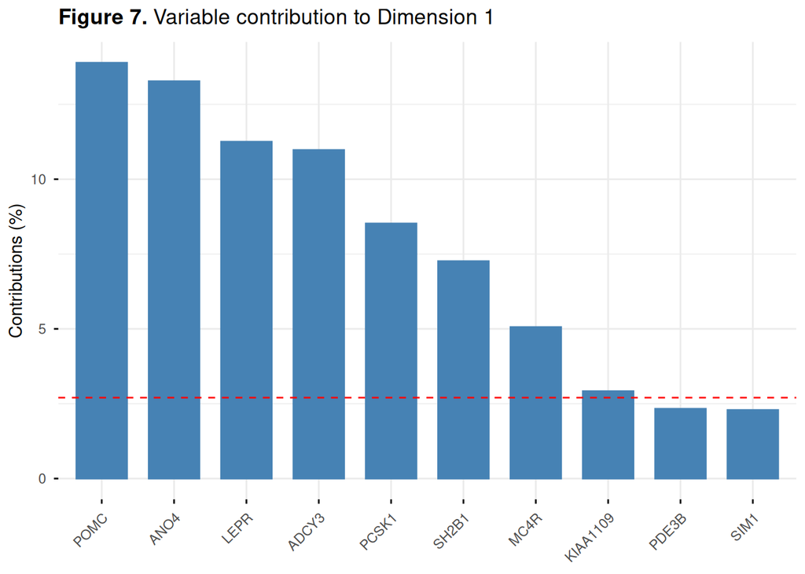

```r
fig_contrib_dim1
```

## 6.3 Clustering Patterns and Heatmaps

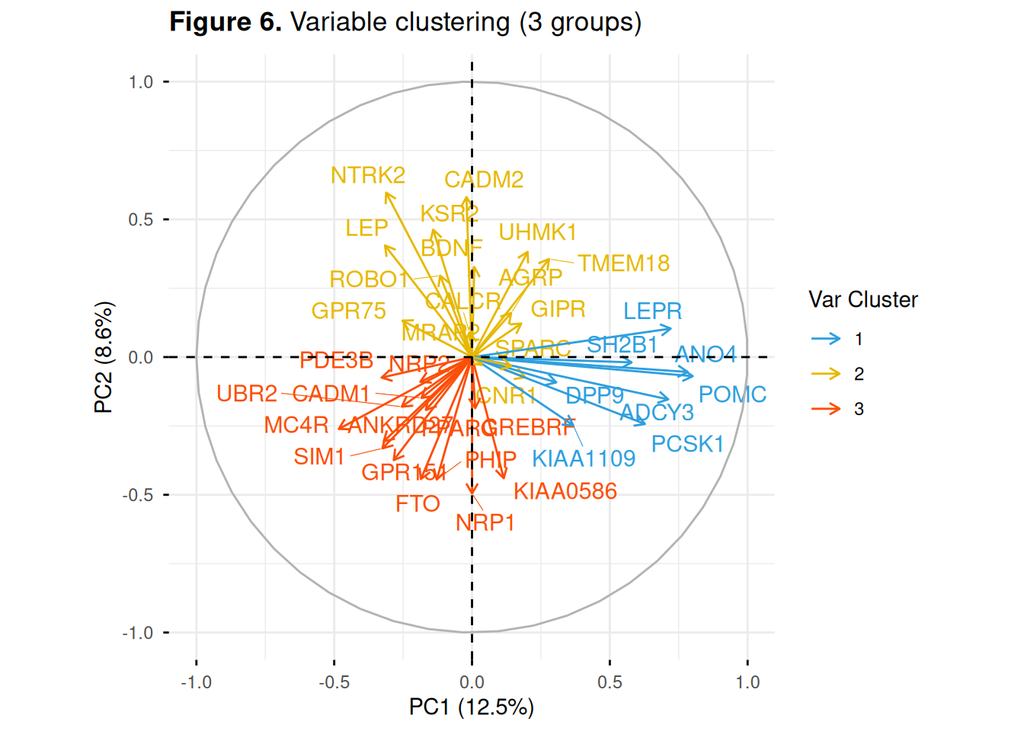

```r
fig_var_cluester
```

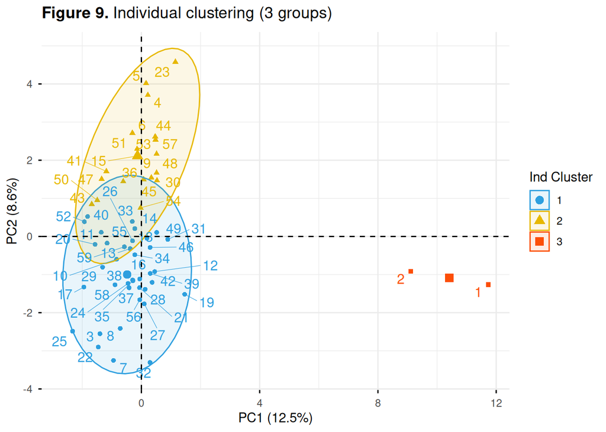

```r
fig_ind_cluster
```

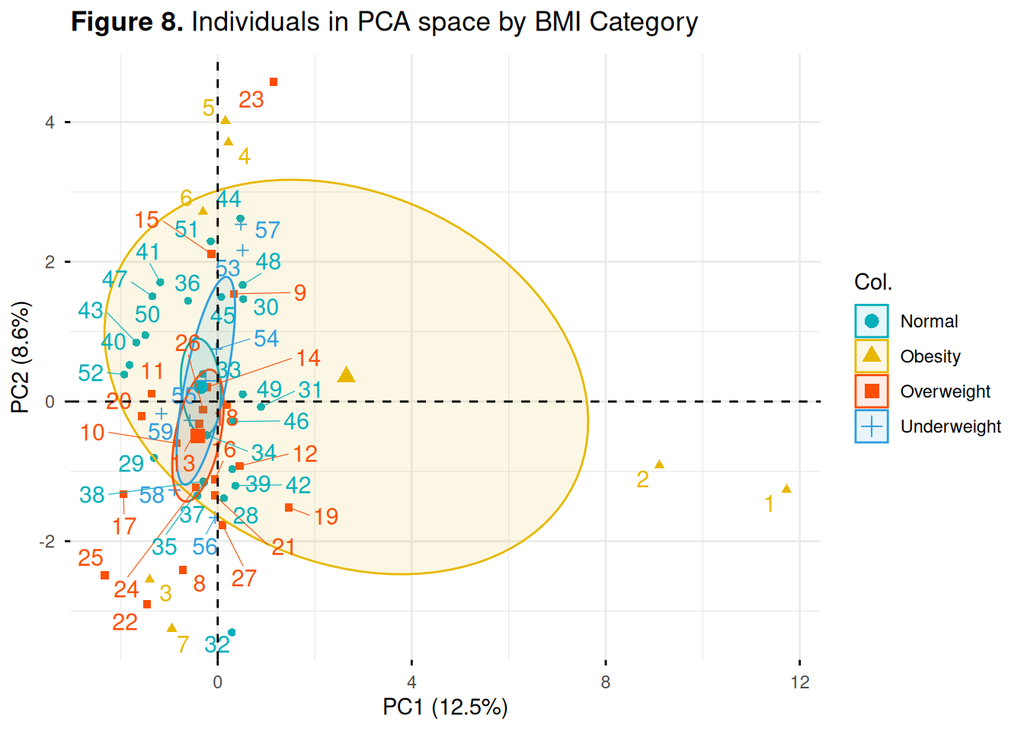

```r
fig_ind_imc
```

To validate the exact relationship between genes and latent dimensions, Figure 10 reveals that the first principal component (PC1) is strongly driven by positive correlations with genes such as *POMC* (0.43) and *LEPR* (0.39), in contrast to marked negative correlations in *GPR151* (-0.43) and *MC4R* (-0.34), which explains the direction of the vectors observed in the spatial analysis. To confirm that this statistical structure reflects a biological reality, Figure 11 displays the standardized matrix, where the overall mosaic visualizes the high sample heterogeneity; however, it strongly highlights at the lower margin that the outlier subjects Patient 1 and Patient 2 concentrate intense red blocks denoting high overexpression in key PC1 genes (such as *POMC* and *LEPR*), accompanied by dark blue blocks in their antagonists. This directly demonstrates with the raw data why these individuals were isolated into a differential cluster associated with obesity in previous models, visually verifying that their clinical phenotype is driven by an extreme and simultaneous transcriptional dysregulation of this specific gene profile.

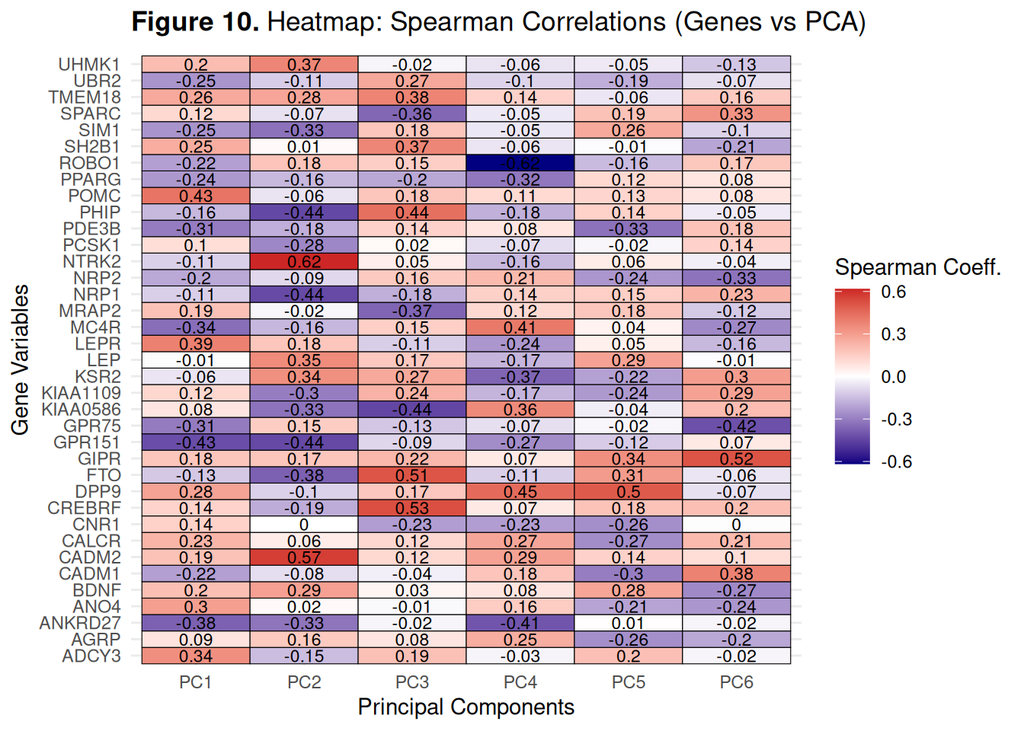

```r
heatmap_spearman
```

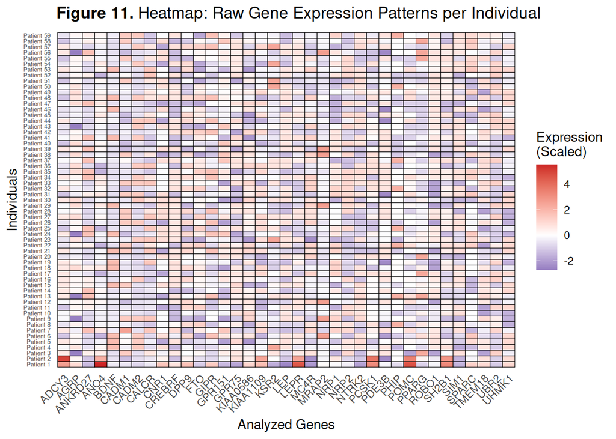

```r
heatmap_crudo
```

## Descriptive Characterization by Genetic Strata

```r
# Overall Descriptive Table (gtsummary)
tabla_descriptiva_final
```

**Descriptive Table.** Stratified descriptive analysis by PCA tertiles

|  | **Component 1** **T1**<sup>1</sup> | **Component 1** **T2**<sup>1</sup> | **Component 1** **T3**<sup>1</sup> | **Component 1** **p-value**<sup>2</sup> | **Component 2** **T1**<sup>1</sup> | **Component 2** **T2**<sup>1</sup> | **Component 2** **T3**<sup>1</sup> | **Component 2** **p-value**<sup>2</sup> | **Component 3** **T1**<sup>1</sup> | **Component 3** **T2**<sup>1</sup> | **Component 3** **T3**<sup>1</sup> | **Component 3** **p-value**<sup>2</sup> |
| --- | --- | --- | --- | --- | --- | --- | --- | --- | --- | --- | --- | --- |
| N | 20 | 19 | 20 |  | 20 | 19 | 20 |  | 20 | 19 | 20 |  |
| ADCY3 | -0.8 (-0.9 - -0.5) | -0.5 (-0.8 - -0.2) | -0.2 (-0.8 - -0.2) | 0.016 | -0.2 (-0.8 - -0.2) | -0.5 (-0.8 - -0.2) | -0.5 (-0.8 - -0.2) | 0.490 | -0.5 (-0.9 - -0.4) | -0.5 (-0.8 - -0.2) | -0.4 (-0.8 - -0.2) | 0.351 |
| AGRP | 0.2 (-0.2 - 0.5) | 0.2 (-0.2 - 0.3) | 0.2 (-0.2 - 0.7) | 0.707 | 0.2 (-0.2 - 0.3) | 0.2 (0.2 - 0.3) | 0.2 (0.0 - 0.7) | 0.550 | 0.2 (-0.2 - 0.6) | 0.3 (0.2 - 0.7) | 0.2 (-0.2 - 0.5) | 0.657 |
| ANKRD27 | 0.8 (-0.2 - 0.8) | -0.2 (-0.4 - 2.1) | -0.4 (-0.4 - -0.2) | 0.046 | 0.3 (-0.2 - 2.1) | 0.8 (-0.4 - 0.8) | -0.4 (-0.4 - -0.2) | 0.040 | -0.2 (-0.4 - 1.5) | -0.2 (-0.4 - 0.8) | -0.2 (-0.4 - 2.1) | 0.719 |
| ANO4 | -0.5 (-0.8 - -0.3) | -0.5 (-0.5 - -0.3) | -0.3 (-0.5 - -0.2) | 0.208 | -0.5 (-0.5 - -0.3) | -0.3 (-0.5 - -0.1) | -0.5 (-0.5 - -0.3) | 0.117 | -0.5 (-0.5 - -0.3) | -0.3 (-0.5 - -0.2) | -0.5 (-0.5 - -0.2) | 0.861 |
| BDNF | -0.8 (-0.9 - -0.7) | -0.8 (-0.9 - -0.7) | -0.7 (-0.8 - 1.2) | 0.208 | -0.8 (-0.9 - -0.7) | -0.7 (-0.9 - -0.7) | -0.7 (-0.8 - 1.2) | 0.154 | -0.8 (-0.9 - 0.3) | -0.7 (-0.8 - 1.2) | -0.8 (-0.9 - -0.7) | 0.587 |
| CADM1 | -0.4 (-0.6 - 1.0) | -0.1 (-0.6 - 1.0) | -0.6 (-0.9 - -0.4) | 0.029 | -0.2 (-0.6 - 1.0) | -0.4 (-0.6 - 1.0) | -0.4 (-0.6 - -0.3) | 0.512 | -0.5 (-0.9 - 1.0) | -0.4 (-0.6 - 1.0) | -0.4 (-0.6 - -0.1) | 0.507 |
| CADM2 | -0.7 (-0.7 - -0.6) | -0.7 (-0.7 - 1.2) | -0.6 (-0.7 - 1.2) | 0.367 | -0.7 (-0.8 - -0.7) | -0.7 (-0.7 - 1.2) | 1.2 (-0.6 - 1.2) | 7.39e-05 | -0.6 (-0.7 - -0.6) | -0.7 (-0.7 - 1.2) | -0.6 (-0.7 - 1.2) | 0.399 |
| CALCR | -0.3 (-1.0 - 1.0) | -0.3 (-0.7 - 1.0) | -0.2 (-0.3 - 1.5) | 0.308 | -0.3 (-0.8 - 1.5) | -0.3 (-0.7 - 1.0) | 0.4 (-0.6 - 1.5) | 0.337 | -0.3 (-0.8 - 1.0) | -0.3 (-0.6 - 2.0) | -0.3 (-0.7 - 1.0) | 0.441 |
| CNR1 | -0.2 (-0.3 - 0.7) | -0.2 (-1.9 - 0.7) | -0.2 (-0.3 - 0.7) | 0.667 | -0.2 (-0.3 - 0.7) | -0.2 (-0.3 - 0.7) | -0.2 (-1.1 - 0.7) | 0.996 | 0.7 (-0.3 - 0.7) | -0.2 (-0.3 - 0.7) | -0.3 (-1.9 - 0.7) | 0.151 |
| CREBRF | 0.4 (-1.4 - 0.7) | 0.6 (-1.4 - 0.7) | 0.7 (-1.4 - 0.8) | 0.322 | 0.7 (0.4 - 0.8) | 0.6 (-1.4 - 0.7) | 0.1 (-1.4 - 0.8) | 0.316 | -1.4 (-1.4 - 0.7) | 0.6 (-1.4 - 0.7) | 0.7 (0.6 - 0.8) | 0.001 |
| DPP9 | -1.2 (-1.5 - -0.2) | 0.7 (-0.3 - 0.8) | -0.1 (-0.7 - 0.8) | 0.025 | 0.3 (-0.7 - 0.8) | -0.3 (-1.2 - 0.7) | -0.3 (-1.2 - 0.8) | 0.302 | -0.3 (-1.5 - 0.8) | -0.3 (-1.2 - 0.7) | 0.7 (-0.7 - 0.8) | 0.369 |
| FTO | 0.6 (0.2 - 0.9) | 0.6 (-0.3 - 0.9) | 0.6 (-0.4 - 0.9) | 0.756 | 0.9 (0.6 - 1.7) | 0.6 (-0.3 - 0.9) | -0.3 (-1.4 - 0.9) | 0.025 | 0.6 (-0.3 - 0.6) | 0.6 (-1.4 - 0.9) | 0.9 (0.8 - 1.7) | 5.46e-04 |
| GIPR | -0.4 (-0.8 - 0.0) | 0.0 (-0.2 - 1.6) | -0.2 (-0.6 - 0.7) | 0.042 | -0.2 (-0.6 - 1.5) | -0.2 (-1.0 - 0.0) | -0.2 (-0.2 - 0.0) | 0.402 | -0.2 (-0.6 - 0.0) | -0.2 (-0.6 - 0.0) | 0.0 (-0.4 - 1.6) | 0.128 |
| GPR151 | 0.4 (0.0 - 0.7) | 0.5 (-0.2 - 0.7) | -0.2 (-1.2 - 0.2) | 0.008 | 0.6 (0.3 - 1.0) | -0.2 (-1.2 - 0.5) | -0.2 (-0.7 - 0.4) | 0.002 | 0.3 (-0.2 - 0.7) | 0.1 (-1.2 - 0.5) | 0.2 (-0.2 - 0.6) | 0.481 |
| GPR75 | 0.6 (0.3 - 0.7) | 0.3 (-1.1 - 0.7) | 0.1 (-1.5 - 0.5) | 0.090 | 0.3 (-1.5 - 0.6) | 0.4 (-1.1 - 0.7) | 0.4 (-0.5 - 0.7) | 0.513 | 0.5 (-0.5 - 0.6) | 0.4 (-1.1 - 0.7) | 0.2 (-1.1 - 0.6) | 0.498 |
| KIAA0586 | 0.5 (-0.5 - 0.8) | 0.7 (-0.5 - 0.9) | 0.7 (-0.5 - 0.9) | 0.822 | 0.8 (0.5 - 0.9) | 0.7 (0.5 - 0.9) | -0.5 (-1.4 - 0.8) | 0.053 | 0.9 (0.6 - 0.9) | 0.5 (-0.5 - 0.9) | 0.3 (-0.5 - 0.7) | 0.019 |
| KIAA1109 | -0.5 (-0.7 - 0.4) | -0.5 (-0.7 - 0.3) | -0.5 (-0.7 - 0.4) | 0.830 | -0.1 (-0.5 - 0.4) | -0.5 (-0.7 - 0.3) | -0.6 (-1.6 - -0.1) | 0.028 | -0.5 (-1.1 - -0.5) | -0.5 (-0.7 - 0.4) | -0.1 (-0.7 - 0.4) | 0.250 |
| KSR2 | -0.2 (-0.6 - 0.2) | 0.0 (-0.4 - 0.6) | -0.2 (-0.8 - 0.2) | 0.570 | -0.4 (-0.8 - 0.1) | -0.2 (-0.4 - 0.0) | 0.2 (-0.4 - 2.0) | 0.041 | -0.3 (-0.8 - -0.2) | 0.0 (-0.2 - 0.6) | 0.0 (-0.4 - 0.6) | 0.027 |
| LEP | 1.0 (-0.5 - 1.1) | 1.0 (-0.7 - 1.1) | 1.0 (0.4 - 1.1) | 0.393 | -0.3 (-0.7 - 1.1) | 1.0 (-0.7 - 1.1) | 1.0 (1.0 - 1.1) | 0.022 | 1.0 (-0.7 - 1.1) | 1.0 (-0.3 - 1.1) | 1.0 (-0.5 - 1.1) | 0.525 |
| LEPR | -0.9 (-0.9 - -0.2) | -0.2 (-0.9 - 0.0) | -0.2 (-0.7 - 0.0) | 0.057 | -0.8 (-0.9 - -0.2) | -0.2 (-0.9 - 0.0) | -0.2 (-0.9 - 0.0) | 0.399 | -0.2 (-0.9 - 0.0) | -0.7 (-0.9 - 0.0) | -0.4 (-0.9 - -0.2) | 0.778 |
| MC4R | 0.5 (0.0 - 1.2) | 0.1 (0.0 - 0.9) | -0.5 (-0.5 - 0.5) | 0.039 | 0.9 (-0.2 - 1.1) | 0.1 (0.0 - 1.2) | 0.1 (-0.2 - 0.9) | 0.771 | 0.0 (-0.5 - 0.9) | 0.1 (0.0 - 1.2) | 0.5 (0.0 - 1.1) | 0.443 |
| MRAP2 | -0.2 (-0.5 - -0.2) | -0.2 (-0.5 - -0.2) | -0.2 (-0.3 - -0.1) | 0.246 | -0.2 (-0.5 - -0.2) | -0.2 (-0.5 - -0.2) | -0.3 (-0.5 - -0.2) | 0.884 | -0.2 (-0.4 - 2.4) | -0.2 (-0.5 - -0.2) | -0.3 (-0.5 - -0.2) | 0.070 |
| NRP1 | 0.7 (0.0 - 0.8) | 0.0 (0.0 - 0.7) | 0.0 (-1.6 - 1.0) | 0.674 | 0.7 (0.0 - 1.3) | 0.7 (0.0 - 0.8) | -1.2 (-1.6 - 0.4) | 0.009 | 0.3 (0.0 - 0.8) | 0.2 (-1.6 - 1.3) | 0.0 (-1.4 - 0.7) | 0.454 |
| NRP2 | 0.9 (-1.2 - 0.9) | -0.6 (-1.7 - 0.9) | -0.9 (-1.2 - 0.5) | 0.326 | -0.6 (-1.4 - 0.9) | -0.6 (-1.2 - 0.9) | -0.1 (-1.4 - 0.9) | 0.914 | -0.9 (-1.4 - 0.9) | -0.6 (-1.2 - 0.9) | 0.8 (-1.2 - 0.9) | 0.399 |
| NTRK2 | 1.1 (-0.4 - 1.1) | -0.4 (-0.6 - 1.3) | 1.1 (-0.6 - 1.1) | 0.943 | -0.4 (-0.6 - -0.4) | 1.1 (-0.6 - 1.1) | 1.1 (1.1 - 1.3) | 4.86e-05 | 1.1 (-0.5 - 1.1) | 1.1 (-0.4 - 1.1) | -0.4 (-0.6 - 1.3) | 0.907 |
| PCSK1 | -0.5 (-1.2 - -0.1) | -0.5 (-1.2 - 0.0) | -0.5 (-0.7 - -0.3) | 0.871 | -0.3 (-0.6 - 0.0) | -0.5 (-1.2 - -0.3) | -0.6 (-1.2 - -0.5) | 0.050 | -0.5 (-1.0 - -0.3) | -0.5 (-0.7 - -0.2) | -0.5 (-1.2 - 0.0) | 0.956 |
| PDE3B | 0.9 (0.3 - 0.9) | 0.3 (0.2 - 0.9) | 0.2 (-0.6 - 0.9) | 0.089 | 0.9 (0.2 - 0.9) | 0.9 (0.2 - 0.9) | 0.3 (0.2 - 0.9) | 0.448 | 0.6 (-0.5 - 0.9) | 0.9 (0.2 - 0.9) | 0.3 (0.2 - 0.9) | 0.900 |
| PHIP | 0.1 (-0.9 - 1.1) | 0.1 (-0.9 - 0.1) | 0.1 (-0.2 - 0.1) | 0.518 | 0.1 (0.1 - 1.1) | 0.1 (-0.9 - 0.1) | -0.2 (-0.9 - 0.1) | 0.019 | 0.1 (-0.9 - 0.1) | 0.1 (-0.9 - 0.1) | 0.1 (0.1 - 2.0) | 0.002 |
| POMC | -0.6 (-0.7 - -0.3) | -0.3 (-0.6 - -0.2) | -0.2 (-0.6 - 0.1) | 0.010 | -0.3 (-0.6 - -0.2) | -0.3 (-0.7 - 0.1) | -0.3 (-0.6 - -0.2) | 0.864 | -0.6 (-0.7 - -0.2) | -0.3 (-0.7 - 0.1) | -0.3 (-0.6 - -0.1) | 0.283 |
| PPARG | -0.4 (-0.8 - 1.2) | -0.4 (-1.0 - 0.1) | -1.0 (-1.1 - -0.4) | 0.064 | -0.4 (-1.0 - 0.3) | -0.4 (-1.0 - 0.1) | -0.7 (-1.1 - -0.2) | 0.258 | -0.4 (-1.0 - 0.4) | -0.4 (-1.0 - 0.1) | -0.4 (-1.0 - -0.2) | 0.510 |
| ROBO1 | 0.6 (-0.5 - 0.7) | 0.6 (0.2 - 0.8) | 0.2 (-1.3 - 0.6) | 0.158 | 0.4 (-1.3 - 0.7) | -0.5 (-2.2 - 0.8) | 0.6 (0.2 - 0.6) | 0.401 | 0.4 (-1.3 - 0.8) | 0.2 (-0.5 - 0.6) | 0.6 (0.2 - 0.8) | 0.527 |
| SH2B1 | -0.3 (-1.1 - -0.1) | -0.2 (-0.9 - -0.1) | -0.2 (-0.9 - 0.0) | 0.317 | -0.2 (-0.9 - -0.1) | -0.2 (-0.9 - -0.1) | -0.2 (-0.9 - 0.0) | 0.917 | -1.1 (-1.3 - -0.2) | -0.1 (-0.2 - 0.1) | -0.2 (-0.9 - -0.1) | 6.07e-04 |
| SIM1 | 1.2 (0.4 - 1.2) | 1.0 (-0.2 - 1.2) | 0.4 (-0.6 - 1.2) | 0.144 | 1.2 (0.4 - 1.2) | 1.0 (-0.2 - 1.2) | 0.4 (-0.7 - 1.2) | 0.155 | -0.2 (-0.2 - 1.2) | 1.0 (-0.9 - 1.2) | 1.2 (1.0 - 1.2) | 0.310 |
| SPARC | -0.1 (-0.3 - 0.0) | 0.0 (-1.2 - 1.1) | 0.0 (-0.7 - 0.9) | 0.687 | 0.0 (-0.3 - 1.1) | 0.0 (-0.2 - 0.8) | -0.3 (-1.2 - 0.8) | 0.195 | 0.0 (-0.1 - 0.9) | 0.0 (-0.2 - 0.8) | -0.3 (-1.2 - 0.4) | 0.050 |
| TMEM18 | -0.3 (-1.3 - 0.2) | 0.7 (-0.3 - 1.0) | 0.6 (-0.4 - 0.8) | 0.030 | -0.3 (-0.7 - 0.9) | -0.2 (-0.7 - 0.8) | 0.7 (-0.3 - 0.8) | 0.179 | -0.7 (-0.7 - 0.7) | 0.6 (-0.7 - 0.7) | 0.8 (-0.3 - 1.0) | 0.014 |
| UBR2 | 0.7 (-0.7 - 1.3) | 0.7 (-0.7 - 1.5) | -0.7 (-0.7 - 0.7) | 0.116 | 0.7 (-0.7 - 1.3) | 0.7 (-0.7 - 1.3) | -0.7 (-0.7 - 1.3) | 0.664 | -0.7 (-0.7 - 0.7) | 0.7 (-0.7 - 1.3) | 0.7 (-0.7 - 1.5) | 0.190 |
| UHMK1 | -0.6 (-0.7 - 0.7) | -0.7 (-2.0 - -0.6) | 0.7 (-0.6 - 0.7) | 0.022 | -0.7 (-2.0 - 0.0) | -0.6 (-0.7 - 0.7) | 0.7 (-0.6 - 0.7) | 0.032 | -0.6 (-1.4 - 0.7) | 0.7 (-0.7 - 0.7) | -0.7 (-1.4 - 0.7) | 0.309 |